# Devoir Econométrie L3 S2 Hétéroscédasticité

Clément Abdherramane, Djawed Mancer, Pierre-Emmanuel Diot

2020-04-05

# Introduction

## Data and descriptive statistics

```
  X     wfood  totexp age size town   sex
1 1 0.4676991 1290941  43    5    2   man
2 2 0.3130226 1277978  40    3    2   man
3 3 0.3764819  845852  28    3    2   man
4 4 0.4396909  527698  60    1    2 woman
5 5 0.4036149 1103220  37    5    2   man
6 6 0.1992503 1768128  35    4    2   man
```

```
       X             wfood            totexp              age
 Min.   :    1   Min.   :0.0000   Min.   :   14601   Min.   :16.00
 1st Qu.: 5994   1st Qu.:0.2583   1st Qu.:  449820   1st Qu.:38.00
 Median :11986   Median :0.3642   Median :  731114   Median :50.00
 Mean   :11986   Mean   :0.3783   Mean   :  865550   Mean   :50.54
 3rd Qu.:17979   3rd Qu.:0.4847   3rd Qu.: 1112533   3rd Qu.:62.00
 Max.   :23972   Max.   :0.9966   Max.   :11397547   Max.   :99.00
      size             town          sex
 Min.   : 1.000   Min.   :1.000   man  :20624
 1st Qu.: 2.000   1st Qu.:2.000   woman: 3347
 Median : 4.000   Median :4.000   NA's :    1
 Mean   : 3.695   Mean   :3.241
 3rd Qu.: 5.000   3rd Qu.:4.000
 Max.   :37.000   Max.   :5.000
```

Data summary

| Name | food |
| --- | --- |
| Number of rows | 23972 |
| Number of columns | 7 |
| _______________________ |  |
| Column type frequency: |  |
| factor | 1 |
| numeric | 6 |
| ________________________ |  |
| Group variables | None |

**Variable type: factor**

| skim_variable | n_missing | complete_rate | ordered | n_unique | top_counts |
| --- | --- | --- | --- | --- | --- |
| sex | 1 | 1 | FALSE | 2 | man: 20624, wom: 3347 |

**Variable type: numeric**

| skim_variable | n_missing | complete_rate | mean | sd | p0 | p25 | p50 | p75 | p100 | hist |
| --- | --- | --- | --- | --- | --- | --- | --- | --- | --- | --- |
| X | 0 | 1 | 11986.50 | 6920.26 | 1 | 5993.75 | 11986.50 | 17979.25 | 23972 | ▇▇▇▇▇ |
| wfood | 0 | 1 | 0.38 | 0.17 | 0 | 0.26 | 0.36 | 0.48 | 1 | ▂▇▆▂▁ |
| totexp | 0 | 1 | 865550.02 | 629562.79 | 14601 | 449820.00 | 731113.50 | 1112533.25 | 11397547 | ▇▁▁▁▁ |
| age | 0 | 1 | 50.54 | 15.11 | 16 | 38.00 | 50.00 | 62.00 | 99 | ▃▇▇▃▁ |
| size | 0 | 1 | 3.70 | 1.79 | 1 | 2.00 | 4.00 | 5.00 | 37 | ▇▁▁▁▁ |
| town | 0 | 1 | 3.24 | 1.22 | 1 | 2.00 | 4.00 | 4.00 | 5 | ▂▃▃▇▂ |

## Data visualisation

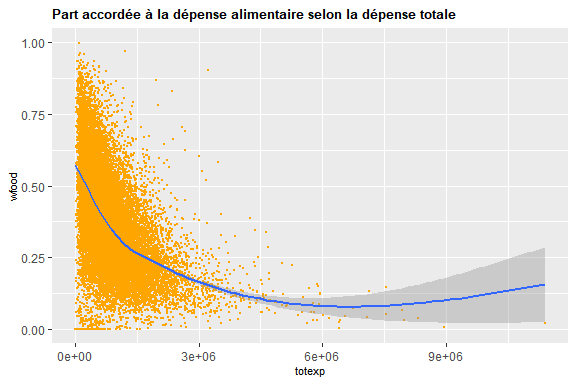

La part du budget consacré à l’alimentation est globalement décroissante en fonction de la dépense totale d’un ménage. Ici on considère que la dépense totale est une proxy du revenu du ménage. Par ailleurs cette première présentation sommaire des données nous indique un risque fort d’hétéroscédasticité étant donné que la variance de la variable wfood est d’autant plus forte que la variable totexp est faible. L’hypothèse de variance constante apparaît très contestable à ce stade de l’analyse…

## First regression

```
##
## Call:
## lm(formula = wfood ~ totexp, data = food)
##
## Residuals:
##      Min       1Q   Median       3Q      Max
## -0.49307 -0.09374 -0.01002  0.08617  1.06182
##
## Coefficients:
##               Estimate Std. Error t value Pr(>|t|)
## (Intercept)  4.950e-01  1.562e-03  316.96   <2e-16 ***
## totexp      -1.348e-07  1.459e-09  -92.41   <2e-16 ***
## ---
## Signif. codes:  0 '***' 0.001 '**' 0.01 '*' 0.05 '.' 0.1 ' ' 1
##
## Residual standard error: 0.1422 on 23970 degrees of freedom
## Multiple R-squared:  0.2627, Adjusted R-squared:  0.2626
## F-statistic:  8540 on 1 and 23970 DF,  p-value: < 2.2e-16
```

## Detecting Heteroskedasticity residual analysis

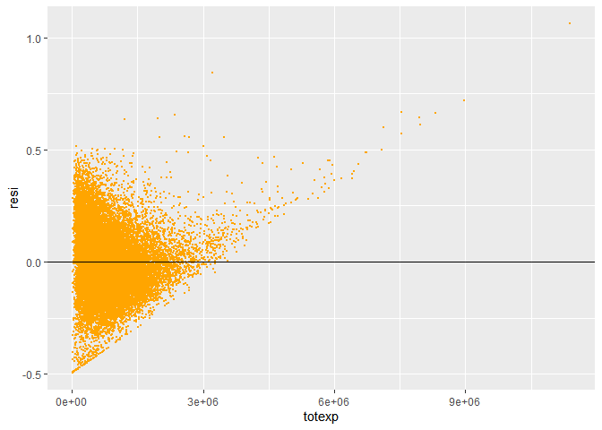

## The Breusch-Pagan Test

```
##
## Call:
## lm(formula = resi^2 ~ totexp, data = food)
##
## Residuals:
##      Min       1Q   Median       3Q      Max
## -0.02114 -0.01823 -0.01204  0.00442  1.11908
##
## Coefficients:
##               Estimate Std. Error t value Pr(>|t|)
## (Intercept)  2.120e-02  3.652e-04  58.062  < 2e-16 ***
## totexp      -1.124e-09  3.412e-10  -3.295 0.000985 ***
## ---
## Signif. codes:  0 '***' 0.001 '**' 0.01 '*' 0.05 '.' 0.1 ' ' 1
##
## Residual standard error: 0.03326 on 23970 degrees of freedom
## Multiple R-squared:  0.0004528,  Adjusted R-squared:  0.0004111
## F-statistic: 10.86 on 1 and 23970 DF,  p-value: 0.0009845
```

```
## [1] 3.841459
```

```
##
##  studentized Breusch-Pagan test
##
## data:  mylm1
## BP = 10.855, df = 1, p-value = 0.0009852
```

## The White Test

```
##
## Call:
## lm(formula = ressq ~ totexp + I(totexp^2), data = food)
##
## Residuals:
##      Min       1Q   Median       3Q      Max
## -0.07764 -0.01666 -0.00856  0.00591  0.68237
##
## Coefficients:
##               Estimate Std. Error t value Pr(>|t|)
## (Intercept)  3.845e-02  4.294e-04   89.54   <2e-16 ***
## totexp      -3.375e-08  5.940e-10  -56.82   <2e-16 ***
## I(totexp^2)  9.597e-15  1.482e-16   64.77   <2e-16 ***
## ---
## Signif. codes:  0 '***' 0.001 '**' 0.01 '*' 0.05 '.' 0.1 ' ' 1
##
## Residual standard error: 0.03068 on 23969 degrees of freedom
## Multiple R-squared:  0.1493, Adjusted R-squared:  0.1493
## F-statistic:  2104 on 2 and 23969 DF,  p-value: < 2.2e-16
```

```
## # A tibble: 1 x 11
##   r.squared adj.r.squared  sigma statistic p.value    df logLik     AIC     BIC
##       <dbl>         <dbl>  <dbl>     <dbl>   <dbl> <int>  <dbl>   <dbl>   <dbl>
## 1     0.149         0.149 0.0307     2104.       0     3 49508. -99007. -98975.
## # ... with 2 more variables: deviance <dbl>, df.residual <int>
```

## Resolving Heteroskedasticity

```
##
## t test of coefficients:
##
##                Estimate  Std. Error t value  Pr(>|t|)
## (Intercept)  4.9504e-01  2.4059e-03 205.764 < 2.2e-16 ***
## totexp      -1.3485e-07  2.5478e-09 -52.928 < 2.2e-16 ***
## ---
## Signif. codes:  0 '***' 0.001 '**' 0.01 '*' 0.05 '.' 0.1 ' ' 1
```

```
##
## Call:
## lm(formula = wfood ~ totexp, data = food, weights = 1/sqrt(varfunc))
##
## Weighted Residuals:
##     Min      1Q  Median      3Q     Max
## -1.5114 -0.3458 -0.0290  0.3296  4.6773
##
## Coefficients:
##               Estimate Std. Error t value Pr(>|t|)
## (Intercept)  4.806e-01  1.539e-03  312.40   <2e-16 ***
## totexp      -1.220e-07  1.310e-09  -93.19   <2e-16 ***
## ---
## Signif. codes:  0 '***' 0.001 '**' 0.01 '*' 0.05 '.' 0.1 ' ' 1
##
## Residual standard error: 0.5197 on 23970 degrees of freedom
## Multiple R-squared:  0.2659, Adjusted R-squared:  0.2659
## F-statistic:  8684 on 1 and 23970 DF,  p-value: < 2.2e-16
```

## Visualizing results

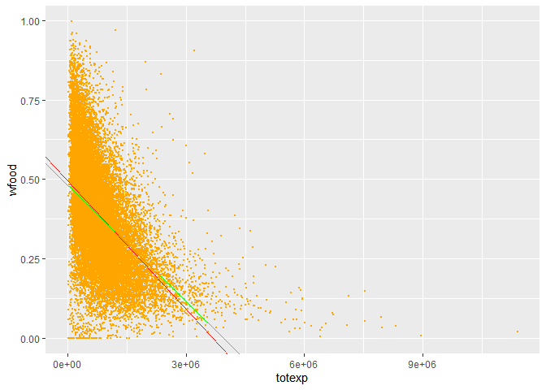

# Question 1

## Data visualisation

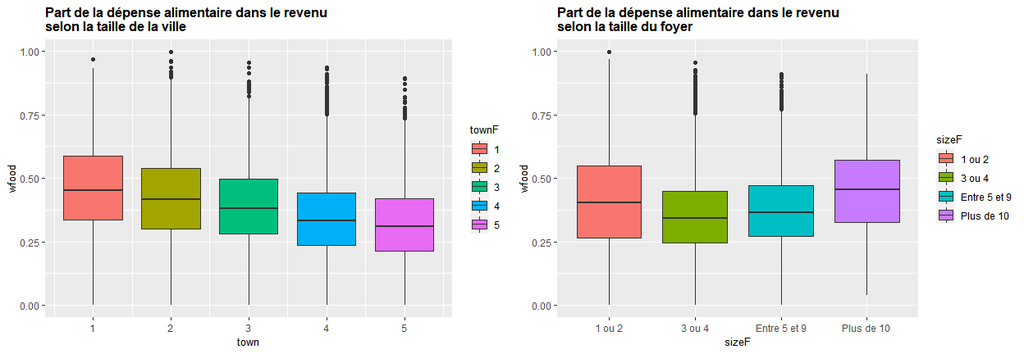

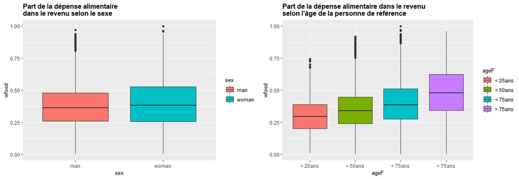

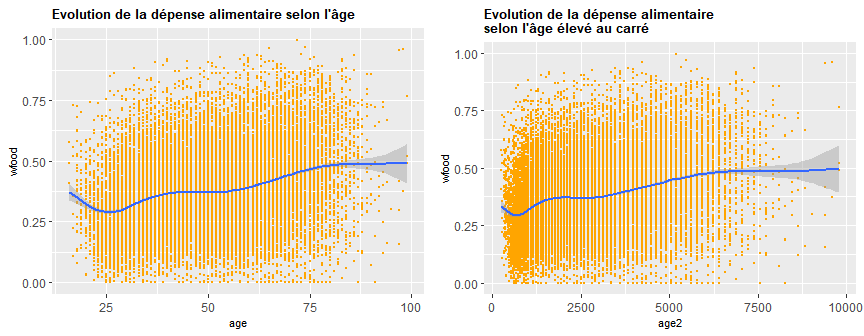

La variance de la variable à expliquer *wfood* en fonction des variables *age* et *age2* semble constante. Il semblerait que l’hytpothèse d’homoscédasticité des résidus soit vérifiée si l’on régresse *wfood* par rapport à *age* ou à *age2*.

## Second regression

Après avoir transformé les variables *age*, *size* et *town*, on décide d’estimer le modèle ‘Niveau-Niveau’ suivant :

$$wfood_{i} = \beta_{0} + \beta_{1}totexp_{i} + \beta_{2}under25_{i} + \beta_{3}under50_{i} +\beta_{4}under75_{i}+ \beta_{5}size1_{i}+\\ \beta_{6}size2_{i}+\beta_{7}town1_{i}+\beta_{8}woman_{i}+\varepsilon_{i}, \ \forall i$$

```
##
## Call:
## lm(formula = wfood ~ totexp + under25 + under50 + under75 + size1 +
##     size2 + town1 + woman, data = food)
##
## Residuals:
##      Min       1Q   Median       3Q      Max
## -0.60452 -0.08991 -0.00959  0.08228  1.15609
##
## Coefficients:
##               Estimate Std. Error t value Pr(>|t|)
## (Intercept)  6.106e-01  4.715e-03 129.507  < 2e-16 ***
## totexp      -1.383e-07  1.530e-09 -90.341  < 2e-16 ***
## under25     -1.159e-01  6.770e-03 -17.120  < 2e-16 ***
## under50     -7.709e-02  3.968e-03 -19.428  < 2e-16 ***
## under75     -3.930e-02  3.763e-03 -10.445  < 2e-16 ***
## size1       -9.383e-02  2.886e-03 -32.510  < 2e-16 ***
## size2       -5.830e-02  2.742e-03 -21.263  < 2e-16 ***
## town1        4.530e-02  1.993e-03  22.738  < 2e-16 ***
## woman       -1.891e-02  2.699e-03  -7.005 2.54e-12 ***
## ---
## Signif. codes:  0 '***' 0.001 '**' 0.01 '*' 0.05 '.' 0.1 ' ' 1
##
## Residual standard error: 0.136 on 23962 degrees of freedom
## Multiple R-squared:  0.3261, Adjusted R-squared:  0.3258
## F-statistic:  1449 on 8 and 23962 DF,  p-value: < 2.2e-16
```

Il est important de noter que les coefficients estimés sont significatifs, ce qui veut dire que le modèle avec toutes les variables est meilleur que le modèle avec seulement la constante en variable explicative. La valeur de la statistique de Fisher a diminué par rapport au modèle avec seulement *totexp* en variable explicative. On la compare à la valeur critique
$$F^{*}=1449 > F^{8,\ 23\ 962}_{0.95} \approx 1.94$$
On peut rejeter l’hypothèse de non significativité des coefficients de notre modèle. Ainsi, au risque de 5% notre modèle est significativement plus efficace que le modèle avec seulement la constante.

$\widehat{\beta_{2}}, \ \widehat{\beta_{3}} \ et \ \widehat{\beta_{4}}$ permettent de différencier la part du budget accordée à l’alimentation selon respectivement l’âge. $\widehat{\beta_{5}}\ ,\ \widehat{\beta_{6}}\ et\ \widehat{\beta_{7}}$ différencient la part du budget accordée à l’alimentation selon respectivement la taille du foyer et la taille de la ville. Enfin, $\widehat{\beta_{7}}$ permet d’étudier les différences de part du budget accordée à l’alimentation selon le genre.

Par exemple un homme qui a entre 25 et 50 ans, vivant dans une grande ville ($size\ge 3$) et dans un foyer comprenant entre 1 et 3 personnes aura d’après notre régression une constante égale à :
$$\widehat{\beta_{0}} + \widehat{\beta_{3}} + \widehat{\beta_{5}} = 6.106 \times 10^{-1} -7.709 \times 10^{-2} - 9.383 \times 10^{-2} \approx 0.44$$

Mathématiquement, la valeur de la constante correspond à la valeur de *wfood* lorsque *totexp* est égal à 0. Economiquement, mieux vaut ne pas interpréter la constante car la part de la dépense totale accordée à l’alimentation a peu de sens lorsque la dépense totale est nulle. Il faudrait centrer les variables pour pouvoir analyser la constante.

On remarque enfin que la valeur de $\widehat{\beta_{1}}$ a très faiblement augmenté en valeur absolue par rapport à la première régression qui ne comprenait que la variable *totexp* comme variable explicative.

On constate aussi une augmentation du coefficient de détermination, ce qui signifie que la part de la variance expliquée dans la variance totale a augmenté.

# Question 2

## Matrice de corrélations

On décide de tracer la matrice des corrélations pour réprésenter les éventuels effets croisés entre les variables. On ne considère que les variables au format numérique.

Matrice de corrélation des variables explicatives et de la variable dépendante

|  | wfood | totexp | under25 | under50 | under75 | size1 | size2 | town1 | woman |
| --- | --- | --- | --- | --- | --- | --- | --- | --- | --- |
| wfood | 1 |  |  |  |  |  |  |  |  |
| totexp | -0.51 | 1 |  |  |  |  |  |  |  |
| under25 | -0.07 | -0.01 | 1 |  |  |  |  |  |  |
| under50 | -0.17 | 0.2 | -0.14 | 1 |  |  |  |  |  |
| under75 | 0.11 | -0.1 | -0.14 | -0.84 | 1 |  |  |  |  |
| size1 | 0.07 | -0.33 | 0.06 | -0.4 | 0.27 | 1 |  |  |  |
| size2 | -0.1 | 0.19 | -0.04 | 0.31 | -0.21 | -0.75 | 1 |  |  |
| town1 | 0.23 | -0.18 | -0.05 | -0.11 | 0.09 | 0.07 | -0.06 | 1 |  |
| woman | 0.05 | -0.19 | 0.03 | -0.2 | 0.09 | 0.29 | -0.21 | -0.02 | 1 |

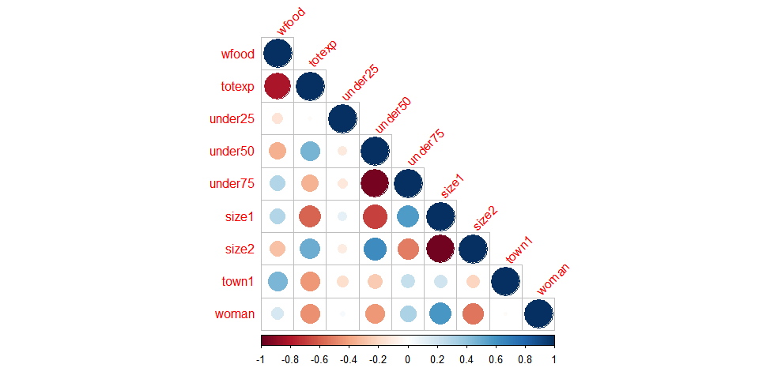

Avant tout, il ne faut pas prendre en compte les corrélations entre dummies correspondant à la même variable.

On remarque que les variables *totexp*, *town1* et *under50* sont les variables les plus corrélées avec la variable à expliquer *wfood*.

La corrélation la plus forte se fait entre la variable à expliquer *wfood* et la variable explicative *totexp*. Cette corrélation est négative car plus la dépense totale augmente, plus la part consacrée à l’alimentation diminue. Cela est en adéquation avec les résultats des deux régressions.

On décide d’ajouter des variables catgéorielles en interaction avec *totexp* dans notre régression.

On décide d’estimer le modèle complet suivant :
$$wfood_{i} = \beta_{0} + \beta_{1}totexp_{i} + \beta_{2}under25_{i} + \beta_{3}under50_{i} + \beta_{4}under75_{i} + \beta_{5}size1 + \\ \beta_{6}size2+ ... + \beta_{K}size_{i}\times woman_{i} + \varepsilon_{i}, \ \forall i$$

```
##
## t test of coefficients:
##
##                    Estimate  Std. Error  t value  Pr(>|t|)
## (Intercept)      5.7559e-01  2.6656e-02  21.5929 < 2.2e-16 ***
## totexp          -1.4716e-07  9.9796e-09 -14.7462 < 2.2e-16 ***
## under25         -9.8790e-02  3.5574e-02  -2.7771 0.0054895 **
## under50         -6.5615e-02  2.6562e-02  -2.4703 0.0135065 *
## under75         -4.9090e-02  2.6650e-02  -1.8421 0.0654775 .
## size1           -4.2911e-02  2.5346e-02  -1.6930 0.0904660 .
## size2           -2.1063e-02  2.7918e-02  -0.7545 0.4505693
## town1            5.3107e-02  9.8602e-03   5.3860 7.273e-08 ***
## woman            7.1280e-03  1.5187e-02   0.4693 0.6388310
## totexp:under25   7.5212e-08  1.3698e-08   5.4908 4.042e-08 ***
## totexp:under50   4.1589e-08  9.7156e-09   4.2807 1.871e-05 ***
## totexp:under75   3.2014e-08  9.6115e-09   3.3308 0.0008674 ***
## totexp:size1    -3.7596e-08  4.2150e-09  -8.9196 < 2.2e-16 ***
## totexp:size2    -1.6336e-08  3.9396e-09  -4.1467 3.384e-05 ***
## totexp:town1    -2.5936e-08  3.7087e-09  -6.9934 2.754e-12 ***
## totexp:woman    -1.0632e-08  5.5915e-09  -1.9014 0.0572582 .
## under25:under50          NA          NA       NA        NA
## under25:under75          NA          NA       NA        NA
## under25:size1   -6.8746e-02  3.3244e-02  -2.0679 0.0386592 *
## under25:size2   -3.9649e-02  3.6361e-02  -1.0904 0.2755356
## under25:town1   -1.8403e-02  1.7973e-02  -1.0239 0.3058883
## under25:woman    1.4297e-02  1.6315e-02   0.8763 0.3808812
## under50:under75          NA          NA       NA        NA
## under50:size1   -4.2643e-02  2.5074e-02  -1.7007 0.0890200 .
## under50:size2   -2.3754e-02  2.7613e-02  -0.8602 0.3896649
## under50:town1    2.6499e-04  8.3718e-03   0.0317 0.9747488
## under50:woman    8.1968e-03  9.4800e-03   0.8646 0.3872429
## under75:size1    1.2268e-02  2.5184e-02   0.4871 0.6261696
## under75:size2   -1.0239e-02  2.7794e-02  -0.3684 0.7125809
## under75:town1   -3.0287e-03  7.7570e-03  -0.3904 0.6962125
## under75:woman   -1.4425e-03  8.0226e-03  -0.1798 0.8573064
## size1:size2              NA          NA       NA        NA
## size1:town1      1.5944e-02  6.5255e-03   2.4433 0.0145602 *
## size1:woman     -3.6182e-02  1.2675e-02  -2.8546 0.0043134 **
## size2:town1      6.0194e-03  6.2865e-03   0.9575 0.3383170
## size2:woman      4.3082e-03  1.3569e-02   0.3175 0.7508628
## town1:woman      1.0000e-02  6.1772e-03   1.6189 0.1054911
## ---
## Signif. codes:  0 '***' 0.001 '**' 0.01 '*' 0.05 '.' 0.1 ' ' 1
```

Cette régression assez fastidieuse permet de déterminer les variables explicatives à garder si l’on souhaite prendre en compte les effets croisés entre ces variables.

- Les coefficients associés aux variables *totexp* et aux dummies correspondant à l’âge sont significatifs (à l’exception de la dummy *under75*)
- Les coefficients associés à la mise en interaction des variables *totexp* et *age*, *totexp* et *size* ainsi que *totexp* et *town1* sont tous significatifs
- Les *NA* correspondent à la mise en intercation de dummies provenant de la même variable catégorielle. Il ne faut pas en tenir compte.

## Third regression

On décide d’estimer le modèle suivant qui permet de différencier l’influence de la dépense totale sur la part accordée à l’alimentation selon différentes caractéristiques sociologiques :
$$wfood_{i} = \beta_{0} + \beta_{1}totexp_{i} + \beta_{2}totexp_{i}\times under25+\beta_{3}totexp_{i}\times under50+\\ \beta_{4}totexp_{i}\times size1 + \beta_{5}totexp_{i}\times size2 + \beta_{6}totexp_{i}\times town1+\varepsilon_{i}, \ \forall i$$

```
##
## Call:
## lm(formula = wfood ~ totexp + totexp:under25 + totexp:under50 +
##     totexp:under75 + totexp:size1 + totexp:size2 + totexp:town1,
##     data = food)
##
## Residuals:
##      Min       1Q   Median       3Q      Max
## -0.50061 -0.09099 -0.01051  0.08158  1.70437
##
## Coefficients:
##                  Estimate Std. Error t value Pr(>|t|)
## (Intercept)     5.032e-01  1.578e-03 318.815  < 2e-16 ***
## totexp         -7.222e-08  6.509e-09 -11.095  < 2e-16 ***
## totexp:under25 -6.186e-08  8.400e-09  -7.365 1.83e-13 ***
## totexp:under50 -3.960e-08  6.254e-09  -6.332 2.47e-10 ***
## totexp:under75 -2.204e-08  6.253e-09  -3.526 0.000423 ***
## totexp:size1   -8.012e-08  2.367e-09 -33.848  < 2e-16 ***
## totexp:size2   -4.019e-08  2.085e-09 -19.275  < 2e-16 ***
## totexp:town1    2.752e-08  2.149e-09  12.807  < 2e-16 ***
## ---
## Signif. codes:  0 '***' 0.001 '**' 0.01 '*' 0.05 '.' 0.1 ' ' 1
##
## Residual standard error: 0.1381 on 23963 degrees of freedom
## Multiple R-squared:  0.3049, Adjusted R-squared:  0.3047
## F-statistic:  1501 on 7 and 23963 DF,  p-value: < 2.2e-16
```

Tous nos coefficients sont significatifs. Le modèle est significatif d’après la statistique de Fisher : $F^{*}=1501 > F^{7,\ 23\ 963}_{0.95} \approx 2$. Le coefficient de détermination est d’environ 30% : la variance expliquée correpond à 30% de la variance totale.

Si l’on considère un individu ayant entre 25 et 50 ans et vivant dans un foyer de 3 personnes ou moins dans une grande ville, l’effet marginal de la dépense totale sur la part accordée à l’alimentation vaut : $\widehat{\beta_{1}}+\widehat{\beta_{3}}+\widehat{\beta_{4}} \approx -1.92\times 10^{-7}$.

# Question 3

## Other regressions

### Fourth regression (Log-Niveau)

Les deux régressions précédentes n’utilisant pas de forme fonctionnelle, on décide d’estimer un modèle Log-Niveau. On conserve les variables de notre dernière régression. Les variables *age*, *size* et *town* sont des variables catégorielles. On utilise encore une fois les dummies créées à partir de ces variables. On estime le modèle Log-Niveau suivant :
$$ln(wfood_{i}) = \beta_{0} + \beta_{1}totexp_{i} + \beta_{2}totexp_{i}\times under25+\beta_{3}totexp_{i}\times under50+\\ \beta_{4}totexp_{i}\times under75+ \beta_{5}totexp_{i}\times size1 + \beta_{6}totexp_{i}\times size2 + \beta_{7}totexp_{i}\times town1+\varepsilon_{i}, \ \forall i$$

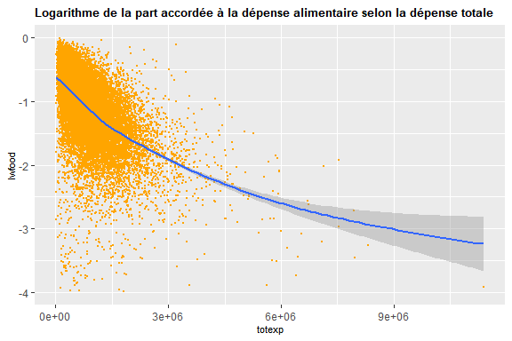

En passant la variable *wfood* au log, la variance de *lwfood* en fonction de *totextp* semble avoir diminué. Le risque d’hétéroscédasticité semble moins important que pour la régression de *wfood* sur *totexp*. Il est possible que l’hypothèse d’homoscédasticité soit vérifiée pour cette régression. Cela sera vérifié lors des tests de la question 4.

```
##
## Call:
## lm(formula = lwfood ~ totexp + totexp:under25 + totexp:under50 +
##     totexp:under75 + totexp:size1 + totexp:size2 + totexp:town1,
##     data = food)
##
## Residuals:
##     Min      1Q  Median      3Q     Max
## -4.7978 -0.1987  0.0529  0.2674  4.6139
##
## Coefficients:
##                  Estimate Std. Error  t value Pr(>|t|)
## (Intercept)    -6.559e-01  4.970e-03 -131.956  < 2e-16 ***
## totexp         -2.727e-07  2.047e-08  -13.321  < 2e-16 ***
## totexp:under25 -1.901e-07  2.641e-08   -7.199 6.25e-13 ***
## totexp:under50 -9.494e-08  1.967e-08   -4.826 1.40e-06 ***
## totexp:under75 -2.558e-08  1.967e-08   -1.301    0.193
## totexp:size1   -3.232e-07  7.444e-09  -43.423  < 2e-16 ***
## totexp:size2   -1.286e-07  6.556e-09  -19.615  < 2e-16 ***
## totexp:town1    6.770e-08  6.760e-09   10.015  < 2e-16 ***
## ---
## Signif. codes:  0 '***' 0.001 '**' 0.01 '*' 0.05 '.' 0.1 ' ' 1
##
## Residual standard error: 0.4342 on 23903 degrees of freedom
## Multiple R-squared:  0.3414, Adjusted R-squared:  0.3412
## F-statistic:  1770 on 7 and 23903 DF,  p-value: < 2.2e-16
```

Tous les coefficients sont significatifs à l’exception de $\beta_{4}$, ce qui est logique car on a supprimé les valeurs infinies de la variable *lwfood*.

Ici, l’effet marginal de *totexp* sur *lwfood* selon les caractéristiques sociologiques représente la semi-élasticité de la part du budget accordée à l’alimentation par rapport à la dépense totale. Cela nous permet de savoir de combien varie *wfood* en % lorsque *totexp* augmente d’une unité.

Si l’on considère un individu ayant entre 25 et 50 ans et vivant dans un foyer de 3 personnes ou moins dans une grande ville, une variation unitaire de *totexp* entraine une variation de *wfood* de : $100\times (e^{\widehat{\beta_{1}}+\widehat{\beta_{3}}+\widehat{\beta_{4}}}-1) \approx -6.91\times 10^{-5}\ \%$.

### Fifth regression (Niveau-Log)

On peut aussi estimer le modèle Niveau-Log suivant :
$$wfood_{i} = \beta_{0} + \beta_{1}ln(totexp_{i}) + \beta_{2}ln(totexp_{i})\times under25+\beta_{3}ln(totexp_{i})\times under50 +\beta_{4}ln(totexp_{i})\times under75 \\ +\beta_{5}ln(totexp_{i})\times size1 + \beta_{6}ln(totexp_{i})\times size2 + \beta_{7}ln(totexp_{i})\times town1+\varepsilon_{i}, \ \forall i$$

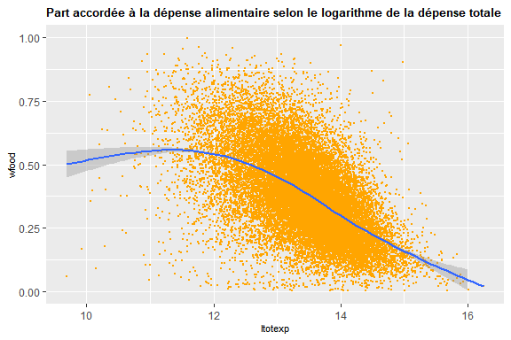

Après avoir passer la variable *totexp* au log, il est possible que la variance de *wfood* selon *ltotexp* soit constante. Le risque d’hétéroscédasticité semble moins important que pour la régression de *wfood* sur *totexp*.

```
##
## Call:
## lm(formula = wfood ~ ltotexp + ltotexp:under25 + ltotexp:under50 +
##     ltotexp:under75 + ltotexp:size1 + ltotexp:size2 + ltotexp:town1,
##     data = food)
##
## Residuals:
##      Min       1Q   Median       3Q      Max
## -0.84435 -0.08302 -0.00729  0.07942  0.67354
##
## Coefficients:
##                   Estimate Std. Error t value Pr(>|t|)
## (Intercept)      2.2694561  0.0183690 123.548  < 2e-16 ***
## ltotexp         -0.1357076  0.0014280 -95.035  < 2e-16 ***
## ltotexp:under25 -0.0040994  0.0004944  -8.292  < 2e-16 ***
## ltotexp:under50 -0.0012828  0.0003019  -4.249 2.15e-05 ***
## ltotexp:under75  0.0005626  0.0002885   1.950   0.0512 .
## ltotexp:size1   -0.0079989  0.0002018 -39.640  < 2e-16 ***
## ltotexp:size2   -0.0039488  0.0001900 -20.785  < 2e-16 ***
## ltotexp:town1    0.0026484  0.0001444  18.346  < 2e-16 ***
## ---
## Signif. codes:  0 '***' 0.001 '**' 0.01 '*' 0.05 '.' 0.1 ' ' 1
##
## Residual standard error: 0.1303 on 23903 degrees of freedom
## Multiple R-squared:  0.3745, Adjusted R-squared:  0.3743
## F-statistic:  2044 on 7 and 23903 DF,  p-value: < 2.2e-16
```

Tous les coefficients sont significatifs à l’exception de $\beta_{4}$, ce qui est logique car on a supprimé les valeurs infinies de la variable *lwfood*.

Ici, l’effet marginal de *totexp* sur *wfood* selon les caractéristiques sociologiques représente la variation de niveau de la part du budget accordée à l’alimentation lorsque la dépense totale augmente de 1%.

### Sixth regression (Log-Log)

Enfin, il semble intéressant d’estimer le modèle Log-Log suivant :
$$ln(wfood_{i}) = \beta_{0} + \beta_{1}ln(totexp_{i}) + \beta_{2}ln(totexp_{i})\times under25+\beta_{3}ln(totexp_{i})\times under50 +\\ \beta_{4}ln(totexp_{i})\times under75 +\beta_{5}ln(totexp_{i})\times size1 + \beta_{6}ln(totexp_{i})\times size2 + \beta_{7}ln(totexp_{i})\times town1+\varepsilon_{i}, \ \forall i$$

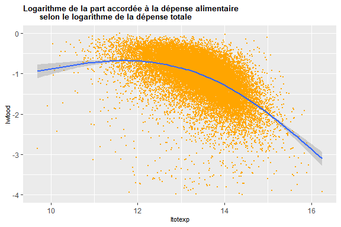

En repésentant le log de *wfood* en fonction du log de *totexp*, on peut penser que l’hypothèse d’homoscédasticité est vérifiée car la variance de *lwfood* semble constante par rapport à *ltotexp*.

```
##
## Call:
## lm(formula = lwfood ~ ltotexp + ltotexp:under25 + ltotexp:under50 +
##     ltotexp:under75 + ltotexp:size1 + ltotexp:size2 + ltotexp:town1,
##     data = food)
##
## Residuals:
##     Min      1Q  Median      3Q     Max
## -4.7864 -0.1984  0.0551  0.2700  1.5319
##
## Coefficients:
##                   Estimate Std. Error t value Pr(>|t|)
## (Intercept)      4.7619551  0.0620884  76.696  < 2e-16 ***
## ltotexp         -0.4206791  0.0048267 -87.157  < 2e-16 ***
## ltotexp:under25 -0.0096548  0.0016710  -5.778 7.65e-09 ***
## ltotexp:under50 -0.0010148  0.0010204  -0.994     0.32
## ltotexp:under75  0.0052815  0.0009751   5.416 6.14e-08 ***
## ltotexp:size1   -0.0285924  0.0006821 -41.921  < 2e-16 ***
## ltotexp:size2   -0.0116971  0.0006422 -18.215  < 2e-16 ***
## ltotexp:town1    0.0060935  0.0004879  12.488  < 2e-16 ***
## ---
## Signif. codes:  0 '***' 0.001 '**' 0.01 '*' 0.05 '.' 0.1 ' ' 1
##
## Residual standard error: 0.4405 on 23903 degrees of freedom
## Multiple R-squared:  0.3222, Adjusted R-squared:  0.322
## F-statistic:  1623 on 7 and 23903 DF,  p-value: < 2.2e-16
```

Tous les coefficients sont significatifs à l’exception de $\beta_{3}$. Cela peut provenir du fait que l’on a supprimé les valeurs infinies de *lwfood*.

Ici l’effet marginal de *totexp* sur *lwfood* représente l’élasticité de la part du budget accordée à l’alimentation par rapport à la dépense totale. Cela nous permet de connaître la variation de *wfood* en % lorsque *totexp* augmente d’1%.

**Conclusion**

Nos 3 dernières régressions donnent des coefficients de détermination et des statistiques de Fisher plus élevés que le modèle Niveau-Niveau correspondant à la régression 3. En termes de significativité du modèle, l’utilisation d’une forme fonctionnelle paraît judicieuse.

La régression Niveau-Log donne le coefficient de détermination le plus élevé et la statistique de Fisher la plus élevée. En effet, la part de la variance expliquée dans la variance totale est de 37,45% pour ce modèle. Toutefois, le coefficient $\beta_{4}$ est peu significatif du fait que la variable explicative *totexp* a été mise au log.

Il faut maintenant déterminer si l’utilisation d’une forme fonctionnelle dans la régression permet de vérifier l’hytpothèse d’homoscédasticité.

# Question 4

## Detecting Heteroskedasticity

### Residual analysis

On choisit d’examiner la présence d’hétéroscédasticité pour la régression 2 avec toutes les variables et pour les 4 derniers modèles étudiés. Il s’agit des modèles faisant intervenir les variables *totexp* (variable quantitative), *age*, *size* et *town* (dummies) comme variables explicatives de *wfood*.

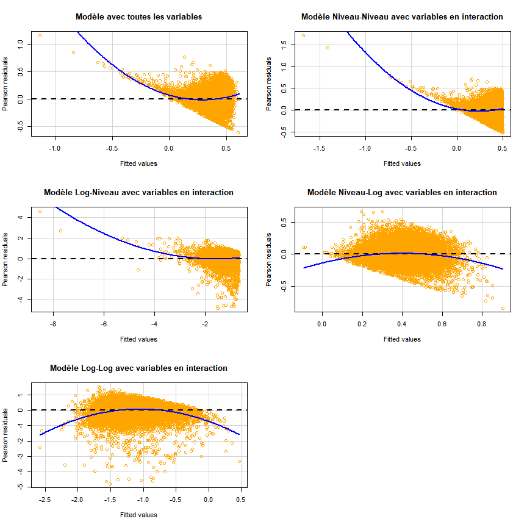

A première vue, ces représentations des résidus de Pearson ($e^{P}_{i}=\frac{e_{i}}{\sigma_{e_{i}}}$) selon les valeurs ajustées des différents modèles semblent indiquer que l’on est en présence d’erreurs hétéroscédastiques. Notons tout de même que l’hétérogénéité de la variance des résidus semble moins prononcée pour le modèle Log-Log.

Pour nos 5 modèles, on choisit de représenter l’évolution des résidus selon la variable *totexp* car il s’agit de la seule variable quantitative du modèle. Les autres variables étant catégorielles, représenter les résidus en fonctions de ces variables aurait très peu d’intérêt.

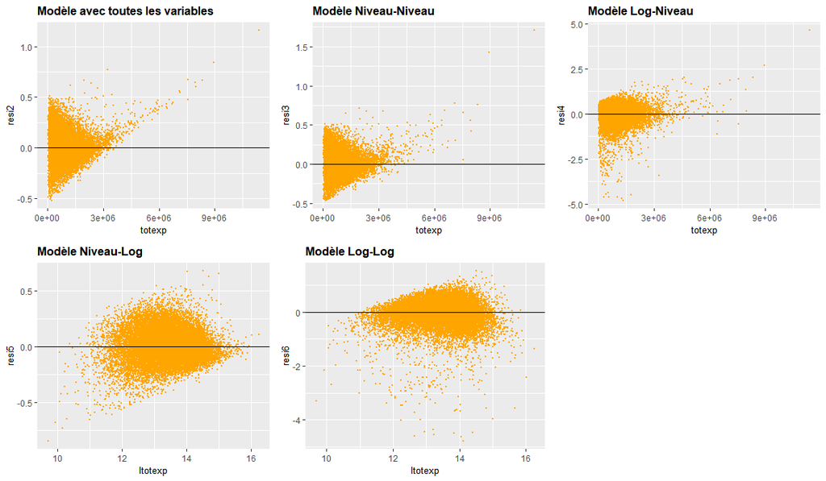

L’introduction d’une forme fonctionnelle logarithmique dans le modèle a une influence sur la variance des résidus. En effet, on remarque que dans les modèles faisant intervenir le log, les résidus sont répartis de manière plus homogène autour de leur espérance.

Afin de détecter toute forme d’hétéroscédasticité des résidus dans ces 5 modèles, on va effectuer successivement le test de Breusch-Pagan puis le test de White.

Les hypothèses des tests sont les suivantes :
$$\left \{
\begin{array}{rcl}
H_0:V(\epsilon_i)=\sigma^2 \\
H_1 :V(\epsilon_i)=\sigma_i^2
\end{array}
\right.$$

### Breusch-Pagan Test

Sous l’hypothèse d’homoscédascticité, on a la régression auxiliaire contrainte :
$$H_0:\ \epsilon^2_j= \delta _0+v$$

**Pour la régression 2**

Sous l’hypothèse d’hétéroscédasticité, on a la régression auxiliaire non-contrainte :
$$H_1:\ \epsilon^2_2= \delta _0 + \delta_1totexp_{i}+\delta_{2}under25_{i} + \delta_{3}under50_{i} +\delta_{4}under75_{i}\\ +\delta_{5}size1_{i}+\delta_{6}size2_{i}+\delta_{7}town1_{i}+\delta_{8}woman_{i}+ w$$
**Pour les régressions 3 à 6**

Sous l’hypothèse d’hétéroscédasticité, on a la régression auxiliaire non-contrainte lorsque *totexp* est en niveau :
$$H_1:\ \epsilon^2_m= \delta _0 + \delta_1totexp+\delta_{2}totexp\times under25+\delta_{3}totexp\times under50+\delta_{4}totexp\times under75 \\ \delta_{5}totexp\times size1 + \delta_{6}totexp\times size2 + \delta_{7}totexp\times town1 + w$$
avec $m$ l’indice de la régression, $m \in \{3;4\}$

Sous l’hypothèse d’hétéroscédasticité, on a la régression auxiliaire non-contrainte lorsque *totexp* est en log :
$$H_1:\ \epsilon^2_n= \delta _0 + \delta_1ln(totexp)+\delta_{2}ln(totexp)\times under25+\delta_{3}ln(totexp)\times under50+\delta_{4}ln(totexp)\times under75 \\ \delta_{5}ln(totexp)\times size1 + \delta_{6}ln(totexp)\times size2 + \delta_{7}ln(totexp)\times town1 + w$$
avec $n$ l’indice de la régression, $n \in \{5;6\}$

Pour tester ces hypothèses, on s’appuie sur 2 tests. Le premier est un test de Fisher pour vérifier la significativité de la régression. La statistique du test est :
$$F^{*}=\frac{R^{2}_{1}}{1-R^{2}_{1}}\times \frac{N-K-1}{q} \leadsto F^{q,\ N-K-1}_{\alpha}$$
avec $N$ le nombre d’observations, $K$ le nombre de variables explicatives dans le modèles et $q$ le nombre de contraintes (ici le nombre de variables explicatives).

Le second test réalisé est un test du $\chi^{2}$ à $K$ degrés de liberté sur la régression de $\epsilon^{2}$ sur les variables explicatives du modèle. Il s’agit de déterminer si certaines variables explicatives contribuent fortement à la valeur des résidus.

Ces deux tests forment le test de Breusch-Pagan.

```
##
## Call:
## lm(formula = resi2^2 ~ totexp + under25 + under50 + under75 +
##     size1 + size2 + town1 + woman, data = food)
##
## Residuals:
##      Min       1Q   Median       3Q      Max
## -0.04025 -0.01554 -0.00886  0.00405  1.27838
##
## Coefficients:
##               Estimate Std. Error t value Pr(>|t|)
## (Intercept)  1.820e-02  1.085e-03  16.776  < 2e-16 ***
## totexp       3.822e-09  3.522e-10  10.851  < 2e-16 ***
## under25     -1.204e-02  1.558e-03  -7.728 1.14e-14 ***
## under50     -1.022e-02  9.131e-04 -11.189  < 2e-16 ***
## under75     -7.669e-03  8.660e-04  -8.855  < 2e-16 ***
## size1        6.606e-03  6.642e-04   9.946  < 2e-16 ***
## size2       -8.748e-04  6.310e-04  -1.386    0.166
## town1        6.369e-03  4.586e-04  13.889  < 2e-16 ***
## woman        5.415e-03  6.212e-04   8.716  < 2e-16 ***
## ---
## Signif. codes:  0 '***' 0.001 '**' 0.01 '*' 0.05 '.' 0.1 ' ' 1
##
## Residual standard error: 0.0313 on 23962 degrees of freedom
## Multiple R-squared:  0.03967,    Adjusted R-squared:  0.03935
## F-statistic: 123.7 on 8 and 23962 DF,  p-value: < 2.2e-16
```

Résultats du test de Breusch-Pagan associé à la régression 2

[output not shown]

```
##
## Call:
## lm(formula = resi3^2 ~ totexp + totexp:under25 + totexp:under50 +
##     totexp:under75 + totexp:size1 + totexp:size2 + totexp:town1,
##     data = food)
##
## Residuals:
##      Min       1Q   Median       3Q      Max
## -0.09938 -0.01492 -0.00951  0.00417  2.74344
##
## Coefficients:
##                  Estimate Std. Error t value Pr(>|t|)
## (Intercept)     1.449e-02  4.339e-04  33.402  < 2e-16 ***
## totexp          6.104e-09  1.789e-09   3.411 0.000648 ***
## totexp:under25  1.744e-08  2.309e-09   7.554 4.37e-14 ***
## totexp:under50 -6.323e-09  1.719e-09  -3.678 0.000236 ***
## totexp:under75 -7.892e-09  1.719e-09  -4.591 4.43e-06 ***
## totexp:size1    1.311e-08  6.507e-10  20.151  < 2e-16 ***
## totexp:size2   -1.849e-10  5.733e-10  -0.322 0.747097
## totexp:town1    3.598e-09  5.908e-10   6.090 1.15e-09 ***
## ---
## Signif. codes:  0 '***' 0.001 '**' 0.01 '*' 0.05 '.' 0.1 ' ' 1
##
## Residual standard error: 0.03797 on 23963 degrees of freedom
## Multiple R-squared:  0.04185,    Adjusted R-squared:  0.04157
## F-statistic: 149.5 on 7 and 23963 DF,  p-value: < 2.2e-16
```

Résultats du test de Breusch-Pagan associé à la régression 3

|  | Statistique | Valeur critique |
| --- | --- | --- |
| Fisher | 149.51 | 2.01 |
| Khi2 | 1003.12 | 14.07 |

Pour la régression de $\epsilon^{2}_{3}$ sur les variables explicatives de la régression 3, tous les coefficients sont significatifs à l’exception de $\delta_6$. On est aussi en présence d’erreurs hétéroscédastiques comme le confirme le test de significativité globale. On trouve $F^{*}_{3} \approx 149.5$ alors que la valeur critique vaut $F^{7,\ 23\ 963}_{0.95} \approx 2$.

Dans les régressions qui vont suivre, la forme fonctionnelle logarithmique a été utilisée. La mise au logarithme de *wfood* a entrainé la suppresion de certaines données. *Food* comporte désormais 23 911 observations. Dans les régressions précédentes, il y avait 23 971 observations.

```
##
## Call:
## lm(formula = resi4^2 ~ totexp + totexp:under25 + totexp:under50 +
##     totexp:under75 + totexp:size1 + totexp:size2 + totexp:town1,
##     data = food)
##
## Residuals:
##     Min      1Q  Median      3Q     Max
## -1.3592 -0.1481 -0.0980 -0.0032 22.6304
##
## Coefficients:
##                  Estimate Std. Error t value Pr(>|t|)
## (Intercept)     8.846e-02  8.314e-03  10.641   <2e-16 ***
## totexp          7.953e-08  3.424e-08   2.323   0.0202 *
## totexp:under25  3.243e-08  4.418e-08   0.734   0.4630
## totexp:under50 -3.765e-08  3.291e-08  -1.144   0.2526
## totexp:under75 -6.328e-08  3.289e-08  -1.924   0.0544 .
## totexp:size1    2.067e-07  1.245e-08  16.601   <2e-16 ***
## totexp:size2    1.358e-08  1.097e-08   1.239   0.2155
## totexp:town1    5.951e-09  1.131e-08   0.526   0.5987
## ---
## Signif. codes:  0 '***' 0.001 '**' 0.01 '*' 0.05 '.' 0.1 ' ' 1
##
## Residual standard error: 0.7263 on 23903 degrees of freedom
## Multiple R-squared:  0.02091,    Adjusted R-squared:  0.02062
## F-statistic: 72.92 on 7 and 23903 DF,  p-value: < 2.2e-16
```

Résultats du test de Breusch-Pagan associé à la régression 4

|  | Statistique | Valeur critique |
| --- | --- | --- |
| Fisher | 72.92 | 2.01 |
| Khi2 | 499.94 | 14.07 |

Pour cette troisième régression auxiliaire, $\epsilon^{2}_{4}$ correspondent aux résidus d’un modèle Log-Niveau. On voit tout de suite que seulement 3 coefficients de la régression auxiliaire sont significatifs. La statistique de Fisher reste tout de même plus élevée que la valeur critique du test mais $F^{*}_{4}<F^{*}_{3}$. On peut en déduire que la mise au logarithme de la variable à expliquer entraine une diminution de la corrélation entre les résidus élevés au carré, ie $V(\epsilon)$, et les variables explicatives du modèle. On peut aller plus loin en supposant que la forme logarithmique tend à faire réduire l’hétéroscédasticité importante de la régression 3. Cette hypothèse est aussi illustrée par la diminution de la statistique du test de Breusch-Pagan version $\chi^2$

```
##
## Call:
## lm(formula = resi5^2 ~ ltotexp + ltotexp:under25 + ltotexp:under50 +
##     ltotexp:under75 + ltotexp:size1 + ltotexp:size2 + ltotexp:town1,
##     data = food)
##
## Residuals:
##      Min       1Q   Median       3Q      Max
## -0.04544 -0.01397 -0.00720  0.00382  0.66005
##
## Coefficients:
##                   Estimate Std. Error t value Pr(>|t|)
## (Intercept)      1.239e-01  4.121e-03  30.071  < 2e-16 ***
## ltotexp         -7.615e-03  3.203e-04 -23.771  < 2e-16 ***
## ltotexp:under25 -5.879e-04  1.109e-04  -5.301 1.16e-07 ***
## ltotexp:under50 -4.399e-04  6.772e-05  -6.496 8.42e-11 ***
## ltotexp:under75 -3.253e-04  6.472e-05  -5.026 5.03e-07 ***
## ltotexp:size1    6.151e-05  4.527e-05   1.359    0.174
## ltotexp:size2   -1.820e-04  4.262e-05  -4.272 1.95e-05 ***
## ltotexp:town1    2.250e-04  3.238e-05   6.950 3.76e-12 ***
## ---
## Signif. codes:  0 '***' 0.001 '**' 0.01 '*' 0.05 '.' 0.1 ' ' 1
##
## Residual standard error: 0.02924 on 23903 degrees of freedom
## Multiple R-squared:  0.0618, Adjusted R-squared:  0.06152
## F-statistic: 224.9 on 7 and 23903 DF,  p-value: < 2.2e-16
```

Résultats du test de Breusch-Pagan associé à la régression 5

|  | Statistique | Valeur critique |
| --- | --- | --- |
| Fisher | 224.92 | 2.01 |
| Khi2 | 1477.67 | 14.07 |

L’ensemble des coefficients de la régression auxiliaire sont significatifs à l’exception de $\delta_5$. De plus la valeur élevée de la statistique de Breusch-Pagan met en avant la présence d’erreurs hétéroscédastiques dans le modèle Niveau-Log.

```
##
## Call:
## lm(formula = resi6^2 ~ ltotexp + ltotexp:under25 + ltotexp:under50 +
##     ltotexp:under75 + ltotexp:size1 + ltotexp:size2 + ltotexp:town1,
##     data = food)
##
## Residuals:
##     Min      1Q  Median      3Q     Max
## -0.3564 -0.1727 -0.1058 -0.0114 22.6232
##
## Coefficients:
##                   Estimate Std. Error t value Pr(>|t|)
## (Intercept)     -0.2633434  0.1036368  -2.541 0.011059 *
## ltotexp          0.0298217  0.0080566   3.702 0.000215 ***
## ltotexp:under25 -0.0009911  0.0027891  -0.355 0.722340
## ltotexp:under50 -0.0010529  0.0017033  -0.618 0.536473
## ltotexp:under75 -0.0032115  0.0016276  -1.973 0.048492 *
## ltotexp:size1    0.0123584  0.0011385  10.855  < 2e-16 ***
## ltotexp:size2    0.0011591  0.0010719   1.081 0.279524
## ltotexp:town1   -0.0002271  0.0008145  -0.279 0.780369
## ---
## Signif. codes:  0 '***' 0.001 '**' 0.01 '*' 0.05 '.' 0.1 ' ' 1
##
## Residual standard error: 0.7353 on 23903 degrees of freedom
## Multiple R-squared:  0.008892,   Adjusted R-squared:  0.008602
## F-statistic: 30.64 on 7 and 23903 DF,  p-value: < 2.2e-16
```

Résultats du test de Breusch-Pagan associé à la régression 6

|  | Statistique | Valeur critique |
| --- | --- | --- |
| Fisher | 30.64 | 2.01 |
| Khi2 | 212.62 | 14.07 |

Dans cette régression auxiliaire des résidus au carré $\epsilon^2_6$ du modèle Log-Log, seuls 2 coefficients sont très significatifs. La statistique de Fisher et celle du test du $\chi^2$ sont nettement moins élevées que pour les autres régressions auxiliaires. Elles restent tout de même supérieures aux valeurs critiques, ce qui nous amène à rejeter l’hypothèse d’homoscédasticité des résidus au risque $\alpha=5\%$. Toutefois, on peut supposer que la mise au logarithme de la variable à expliquer *wfood* et de la seule variable explicative quantitative *totexp* conduit à une diminution de l’hétéroscédasticité des résidus.

### White Test

Le Test de White consiste à régresser les résidus élevés au carré par rapport au variables explicatives et en y ajoutant les variables explicatives au carré et les variables explicatives en interaction. On mettra seulement la variable *totexp* ou *ltotexp* au carré car les autres variables sont des dummies.

Sous l’hypothèse d’homoscédascticité, on a la régression auxiliaire contrainte :
$$H_0:\ \epsilon^2_j= \delta _0+v$$
avec $j$ l’indice de la régression, $j \in \{2;6\}$.

**Pour la régression 2**

Sous l’hypothèse d’hétéroscédasticité, on a la régression auxiliaire non-contrainte :
$$H_1:\ \epsilon^2_2= \delta _0 + \delta_1totexp+\delta_{2}under25_{i} +...+\delta_{8}woman+\delta_9totexp^2\\ +\delta_{10}totexp\times under25+...+\delta_{33}town1\times woman +w$$

**Pour les régressions 3 à 6**

Sous l’hypothèse d’hétéroscédasticité, on a la régression auxiliaire non-contrainte lorsque *totexp* est en niveau :
$$H_1:\ \epsilon^2_m= \delta _0 + \delta_1totexp+\delta_{2}totexp\times under25+...+\delta_{7}totexp\times town1+\\ \delta_8totexp^2+\delta_9(totexp\times under25)^2+...+\delta_{19}totexp\times size2\times town1+w$$
avec $m \in \{3;4\}$

Sous l’hypothèse d’hétéroscédasticité, on a la régression auxiliaire non-contrainte lorsque *totexp* est en log :
$$H_1:\ \epsilon^2_n= \delta _0 + \delta_1ln(totexp)+\delta_{2}ln(totexp)\times under25+...+\delta_{7}ln(totexp)\times town1+\\ \delta_8(ln(totexp))^2+\delta_9(ln(totexp)\times under25)^2+...+\delta_{19}ln(totexp)\times size2\times town1+w$$
avec $n \in \{5;6\}$

```
##
## t test of coefficients:
##
##                    Estimate  Std. Error  t value  Pr(>|t|)
## (Intercept)      3.0043e-02  5.6923e-03   5.2778 1.319e-07 ***
## totexp          -3.2975e-08  2.1901e-09 -15.0562 < 2.2e-16 ***
## under25         -2.2183e-03  7.5980e-03  -0.2920  0.770321
## under50          6.2631e-03  5.6681e-03   1.1050  0.269184
## under75          1.0206e-02  5.6861e-03   1.7949  0.072689 .
## size1            6.9830e-03  5.4076e-03   1.2913  0.196602
## size2            4.5409e-03  5.9543e-03   0.7626  0.445699
## town1           -9.0081e-04  2.1035e-03  -0.4282  0.668483
## woman            2.2955e-03  3.2399e-03   0.7085  0.478643
## I(totexp^2)      9.7155e-15  1.4921e-16  65.1113 < 2.2e-16 ***
## totexp:under25   6.6238e-09  2.9436e-09   2.2502  0.024443 *
## totexp:under50  -1.9907e-09  2.0768e-09  -0.9585  0.337806
## totexp:under75  -3.5506e-09  2.0527e-09  -1.7297  0.083693 .
## totexp:size1     5.7200e-09  9.0571e-10   6.3155 2.741e-10 ***
## totexp:size2     2.2805e-09  8.4656e-10   2.6939  0.007067 **
## totexp:town1     3.5670e-09  7.9162e-10   4.5059 6.639e-06 ***
## totexp:woman    -1.8741e-09  1.1956e-09  -1.5675  0.117006
## under25:under50          NA          NA       NA        NA
## under25:under75          NA          NA       NA        NA
## under25:size1   -1.0812e-02  7.0902e-03  -1.5249  0.127299
## under25:size2   -8.6795e-03  7.7545e-03  -1.1193  0.263033
## under25:town1   -2.4519e-03  3.8329e-03  -0.6397  0.522364
## under25:woman   -2.3182e-03  3.4793e-03  -0.6663  0.505225
## under50:under75          NA          NA       NA        NA
## under50:size1   -1.1156e-02  5.3472e-03  -2.0864  0.036955 *
## under50:size2   -8.5113e-03  5.8888e-03  -1.4453  0.148378
## under50:town1    6.1003e-04  1.7857e-03   0.3416  0.732639
## under50:woman    2.3877e-03  2.0219e-03   1.1809  0.237642
## under75:size1   -1.3457e-02  5.3709e-03  -2.5054  0.012237 *
## under75:size2   -9.0523e-03  5.9275e-03  -1.5272  0.126735
## under75:town1    9.6014e-04  1.6544e-03   0.5803  0.561685
## under75:woman    1.8270e-03  1.7113e-03   1.0676  0.285720
## size1:size2              NA          NA       NA        NA
## size1:town1      3.1503e-03  1.3916e-03   2.2638  0.023598 *
## size1:woman      4.4058e-04  2.7031e-03   0.1630  0.870525
## size2:town1     -1.4760e-03  1.3407e-03  -1.1009  0.270933
## size2:woman      5.9885e-04  2.8937e-03   0.2070  0.836049
## town1:woman     -2.0127e-03  1.3177e-03  -1.5274  0.126663
## ---
## Signif. codes:  0 '***' 0.001 '**' 0.01 '*' 0.05 '.' 0.1 ' ' 1
```

Résultats du test de White associé à la régression 2

|  | Statistique | Valeur critique |
| --- | --- | --- |
| Fisher | 173.41 | 1.44 |
| Khi2 | 4625.12 | 47.40 |

```
##
## t test of coefficients:
##
##                           Estimate  Std. Error  t value  Pr(>|t|)
## (Intercept)             4.1781e-02  4.7563e-04  87.8441 < 2.2e-16 ***
## totexp                 -5.5279e-08  3.7715e-09 -14.6572 < 2.2e-16 ***
## I(totexp^2)             1.4657e-14  1.5926e-16  92.0372 < 2.2e-16 ***
## totexp:under25          5.2048e-09  5.4318e-09   0.9582 0.3379669
## totexp:under50          4.6256e-09  3.7560e-09   1.2315 0.2181405
## totexp:under75          4.1299e-10  3.7699e-09   0.1095 0.9127679
## totexp:size1            1.5005e-08  4.0675e-09   3.6889 0.0002257 ***
## totexp:size2            7.3666e-09  5.0363e-09   1.4627 0.1435665
## totexp:town1            1.4302e-08  3.2864e-09   4.3518 1.356e-05 ***
## totexp:under25:under50          NA          NA       NA        NA
## totexp:under25:under75          NA          NA       NA        NA
## totexp:under25:size1    2.3388e-08  5.8745e-09   3.9813 6.873e-05 ***
## totexp:under25:size2   -3.0183e-09  6.8784e-09  -0.4388 0.6608020
## totexp:under25:town1   -2.1839e-08  5.3435e-09  -4.0870 4.385e-05 ***
## totexp:under50:under75          NA          NA       NA        NA
## totexp:under50:size1   -2.1064e-09  4.1228e-09  -0.5109 0.6094090
## totexp:under50:size2   -4.8806e-09  5.0630e-09  -0.9640 0.3350731
## totexp:under50:town1   -9.6333e-09  3.2208e-09  -2.9910 0.0027835 **
## totexp:under75:size1   -3.4267e-09  4.1211e-09  -0.8315 0.4056998
## totexp:under75:size2   -1.0472e-09  5.0843e-09  -0.2060 0.8368124
## totexp:under75:town1   -6.2103e-09  3.1994e-09  -1.9411 0.0522574 .
## totexp:size1:size2              NA          NA       NA        NA
## totexp:size1:town1     -5.5793e-09  1.3856e-09  -4.0265 5.678e-05 ***
## totexp:size2:town1     -6.1171e-09  1.2803e-09  -4.7779 1.782e-06 ***
## ---
## Signif. codes:  0 '***' 0.001 '**' 0.01 '*' 0.05 '.' 0.1 ' ' 1
```

Résultats du test de White associé à la régression 3

|  | Statistique | Valeur critique |
| --- | --- | --- |
| Fisher | 540.82 | 1.59 |
| Khi2 | 7196.82 | 30.14 |

```
##
## t test of coefficients:
##
##                           Estimate  Std. Error t value  Pr(>|t|)
## (Intercept)             2.2412e-01  1.0574e-02 21.1949 < 2.2e-16 ***
## totexp                 -2.3780e-07  8.3654e-08 -2.8427  0.004477 **
## I(totexp^2)             7.1241e-14  3.5347e-15 20.1546 < 2.2e-16 ***
## totexp:under25         -1.0184e-09  1.2047e-07 -0.0085  0.993255
## totexp:under50          1.8592e-08  8.3308e-08  0.2232  0.823403
## totexp:under75          1.3730e-08  8.3615e-08  0.1642  0.869573
## totexp:size1            2.5483e-07  9.0224e-08  2.8245  0.004740 **
## totexp:size2            3.1509e-08  1.1170e-07  0.2821  0.777881
## totexp:town1            4.0808e-08  7.2944e-08  0.5594  0.575864
## totexp:under25:under50          NA          NA      NA        NA
## totexp:under25:under75          NA          NA      NA        NA
## totexp:under25:size1    3.6304e-08  1.3030e-07  0.2786  0.780533
## totexp:under25:size2    2.3935e-08  1.5256e-07  0.1569  0.875329
## totexp:under25:town1   -3.8221e-09  1.1855e-07 -0.0322  0.974280
## totexp:under50:under75          NA          NA      NA        NA
## totexp:under50:size1   -5.8886e-09  9.1454e-08 -0.0644  0.948661
## totexp:under50:size2    5.5964e-09  1.1229e-07  0.0498  0.960252
## totexp:under50:town1   -3.6559e-08  7.1497e-08 -0.5113  0.609120
## totexp:under75:size1   -9.6136e-08  9.1413e-08 -1.0517  0.292965
## totexp:under75:size2   -3.5921e-09  1.1277e-07 -0.0319  0.974588
## totexp:under75:town1   -3.8961e-09  7.1017e-08 -0.0549  0.956249
## totexp:size1:size2              NA          NA      NA        NA
## totexp:size1:town1     -3.9770e-08  3.0764e-08 -1.2928  0.196106
## totexp:size2:town1     -2.2620e-08  2.8396e-08 -0.7966  0.425697
## ---
## Signif. codes:  0 '***' 0.001 '**' 0.01 '*' 0.05 '.' 0.1 ' ' 1
```

Résultats du test de White associé à la régression 4

|  | Statistique | Valeur critique |
| --- | --- | --- |
| Fisher | 50.45 | 1.59 |
| Khi2 | 922.30 | 30.14 |

```
##
## t test of coefficients:
##
##                            Estimate  Std. Error  t value Pr(>|t|)
## (Intercept)              8.4907e-01  4.2827e-02  19.8258   <2e-16 ***
## ltotexp                 -1.1780e-01  6.4499e-03 -18.2645   <2e-16 ***
## I(ltotexp^2)             4.1216e-03  2.4181e-04  17.0449   <2e-16 ***
## ltotexp:under25          1.6129e-04  4.9069e-04   0.3287   0.7424
## ltotexp:under50          2.2238e-04  3.6555e-04   0.6083   0.5430
## ltotexp:under75          2.6675e-04  3.6771e-04   0.7254   0.4682
## ltotexp:size1            5.7927e-04  3.6822e-04   1.5732   0.1157
## ltotexp:size2            4.6870e-04  4.2790e-04   1.0954   0.2734
## ltotexp:town1            2.4130e-04  1.5183e-04   1.5893   0.1120
## ltotexp:under25:under50          NA          NA       NA       NA
## ltotexp:under25:under75          NA          NA       NA       NA
## ltotexp:under25:size1   -5.0042e-04  5.0340e-04  -0.9941   0.3202
## ltotexp:under25:size2   -6.1112e-04  5.6805e-04  -1.0758   0.2820
## ltotexp:under25:town1   -1.8744e-04  2.8749e-04  -0.6520   0.5144
## ltotexp:under50:under75          NA          NA       NA       NA
## ltotexp:under50:size1   -4.9637e-04  3.7149e-04  -1.3361   0.1815
## ltotexp:under50:size2   -5.7920e-04  4.2978e-04  -1.3476   0.1778
## ltotexp:under50:town1    5.3442e-05  1.3649e-04   0.3916   0.6954
## ltotexp:under75:size1   -4.4357e-04  3.7205e-04  -1.1922   0.2332
## ltotexp:under75:size2   -5.4062e-04  4.3265e-04  -1.2496   0.2115
## ltotexp:under75:town1    7.0780e-05  1.2880e-04   0.5495   0.5826
## ltotexp:size1:size2              NA          NA       NA       NA
## ltotexp:size1:town1     -1.3337e-05  9.8697e-05  -0.1351   0.8925
## ltotexp:size2:town1     -1.5884e-04  9.7312e-05  -1.6323   0.1026
## ---
## Signif. codes:  0 '***' 0.001 '**' 0.01 '*' 0.05 '.' 0.1 ' ' 1
```

Résultats du test de White associé à la régression 5

|  | Statistique | Valeur critique |
| --- | --- | --- |
| Fisher | 100.09 | 1.59 |
| Khi2 | 1763.11 | 30.14 |

```
##
## t test of coefficients:
##
##                           Estimate Std. Error  t value Pr(>|t|)
## (Intercept)             17.9170948  1.0772739  16.6319   <2e-16 ***
## ltotexp                 -2.7128319  0.1622433 -16.7208   <2e-16 ***
## I(ltotexp^2)             0.1027948  0.0060825  16.9001   <2e-16 ***
## ltotexp:under25          0.0005088  0.0123429   0.0412   0.9671
## ltotexp:under50          0.0012912  0.0091951   0.1404   0.8883
## ltotexp:under75          0.0021609  0.0092496   0.2336   0.8153
## ltotexp:size1            0.0131895  0.0092622   1.4240   0.1545
## ltotexp:size2            0.0064966  0.0107634   0.6036   0.5461
## ltotexp:town1           -0.0015985  0.0038192  -0.4185   0.6756
## ltotexp:under25:under50         NA         NA       NA       NA
## ltotexp:under25:under75         NA         NA       NA       NA
## ltotexp:under25:size1    0.0050003  0.0126626   0.3949   0.6929
## ltotexp:under25:size2   -0.0032223  0.0142888  -0.2255   0.8216
## ltotexp:under25:town1    0.0025380  0.0072316   0.3510   0.7256
## ltotexp:under50:under75         NA         NA       NA       NA
## ltotexp:under50:size1    0.0042458  0.0093446   0.4544   0.6496
## ltotexp:under50:size2   -0.0030253  0.0108109  -0.2798   0.7796
## ltotexp:under50:town1    0.0036809  0.0034332   1.0721   0.2837
## ltotexp:under75:size1   -0.0028179  0.0093587  -0.3011   0.7633
## ltotexp:under75:size2   -0.0048567  0.0108829  -0.4463   0.6554
## ltotexp:under75:town1    0.0034060  0.0032398   1.0513   0.2931
## ltotexp:size1:size2             NA         NA       NA       NA
## ltotexp:size1:town1     -0.0022567  0.0024826  -0.9090   0.3634
## ltotexp:size2:town1     -0.0018579  0.0024478  -0.7590   0.4478
## ---
## Signif. codes:  0 '***' 0.001 '**' 0.01 '*' 0.05 '.' 0.1 ' ' 1
```

Résultats du test de White associé à la régression 6

|  | Statistique | Valeur critique |
| --- | --- | --- |
| Fisher | 27.27 | 1.59 |
| Khi2 | 507.56 | 30.14 |

En se focalisant sur la régression auxiliaire du modèle Niveau-Niveau avec variables en interaction, on remarque à nouveau une forte corrélation aux résidus des 2 variables citées précédemment. Toutefois, on en trouve plein d’autres. Ici, les intéractions entre la dépense totale du ménage et le fait d’être habitant d’une petite ville, de faire partie d’un ménage de moins de 4 personnes en ayant moins de 25 ans, d’habiter dans une petite ville et d’avoir moins de 25 ans, d’habiter dans une petite ville peu importe la taille du foyer sont corrélées avec les résidus.

Enfin, les modèles Log-Niveau et Log-Log présentent les statistiques de test les plus faibles. On peut dire que la mise au logarithme de la variable à expliquer entraine une diminution des corrélations entre la variance des résidus et les variables explicatives des différents modèles. Cela confirme l’hytpothèse que l’introduction d’une forme logarithmique dans le modèle - notamment pour la variable dépendante *wfood* - tend à réduire l’hétéroscédasticité des résidus.

## Resolving Heteroskedasticity

Pour chaque modèle, les résultats du premier test de Wald correspondent à la régression utilisant la méthode des MCO et et les résultats du second test de Wald correspondent à la régression utilisant la méthode des MCP. Nous utiliserons ces tests afin d’étudier l’évolution des écarts-types estimés après correction du modèle.

### Niveau-Niveau

```
##
## t test of coefficients:
##
##                Estimate  Std. Error  t value  Pr(>|t|)
## (Intercept)  6.1064e-01  5.8995e-03 103.5068 < 2.2e-16 ***
## totexp      -1.3827e-07  2.9935e-09 -46.1894 < 2.2e-16 ***
## under25     -1.1591e-01  6.9343e-03 -16.7157 < 2.2e-16 ***
## under50     -7.7086e-02  4.8522e-03 -15.8866 < 2.2e-16 ***
## under75     -3.9304e-02  4.7510e-03  -8.2727 < 2.2e-16 ***
## size1       -9.3829e-02  2.9641e-03 -31.6548 < 2.2e-16 ***
## size2       -5.8302e-02  2.4857e-03 -23.4550 < 2.2e-16 ***
## town1        4.5305e-02  2.1966e-03  20.6248 < 2.2e-16 ***
## woman       -1.8909e-02  3.1005e-03  -6.0987 1.086e-09 ***
## ---
## Signif. codes:  0 '***' 0.001 '**' 0.01 '*' 0.05 '.' 0.1 ' ' 1
```

```
##
## t test of coefficients:
##
##                Estimate  Std. Error  t value  Pr(>|t|)
## (Intercept)  6.0090e-01  6.0082e-03 100.0136 < 2.2e-16 ***
## totexp      -1.2818e-07  3.1801e-09 -40.3055 < 2.2e-16 ***
## under25     -1.1419e-01  6.9187e-03 -16.5049 < 2.2e-16 ***
## under50     -7.7837e-02  4.7802e-03 -16.2834 < 2.2e-16 ***
## under75     -4.1589e-02  4.6856e-03  -8.8760 < 2.2e-16 ***
## size1       -9.3579e-02  3.0146e-03 -31.0422 < 2.2e-16 ***
## size2       -5.8011e-02  2.4661e-03 -23.5231 < 2.2e-16 ***
## town1        4.4453e-02  2.1562e-03  20.6167 < 2.2e-16 ***
## woman       -1.6818e-02  2.9880e-03  -5.6287 1.836e-08 ***
## ---
## Signif. codes:  0 '***' 0.001 '**' 0.01 '*' 0.05 '.' 0.1 ' ' 1
```

Résultats du test de Breusch-Pagan associé à la régression 2

|  | Statistique | Valeur critique | p-value |
| --- | --- | --- | --- |
| MCO | 950.86 | 14.07 | 0 |
| MCP | 950.86 | 14.07 | 0 |

La diminution de la variablité des coefficients estimés n’a pas lieu pour tous les coefficients après correction du modèle.

```
##
## t test of coefficients:
##
##                   Estimate  Std. Error  t value  Pr(>|t|)
## (Intercept)     5.0316e-01  3.3344e-03 150.9000 < 2.2e-16 ***
## totexp         -7.2218e-08  7.7576e-09  -9.3093 < 2.2e-16 ***
## totexp:under25 -6.1863e-08  2.3521e-08  -2.6301  0.008541 **
## totexp:under50 -3.9601e-08  7.6896e-09  -5.1500 2.626e-07 ***
## totexp:under75 -2.2044e-08  7.5529e-09  -2.9186  0.003519 **
## totexp:size1   -8.0118e-08  4.7488e-09 -16.8714 < 2.2e-16 ***
## totexp:size2   -4.0195e-08  2.1505e-09 -18.6904 < 2.2e-16 ***
## totexp:town1    2.7522e-08  2.8906e-09   9.5210 < 2.2e-16 ***
## ---
## Signif. codes:  0 '***' 0.001 '**' 0.01 '*' 0.05 '.' 0.1 ' ' 1
```

```
##
## t test of coefficients:
##
##                   Estimate  Std. Error  t value  Pr(>|t|)
## (Intercept)     4.8917e-01  3.8221e-03 127.9829 < 2.2e-16 ***
## totexp         -6.8559e-08  7.4314e-09  -9.2256 < 2.2e-16 ***
## totexp:under25 -4.8807e-08  2.4952e-08  -1.9561   0.05047 .
## totexp:under50 -3.3522e-08  7.4951e-09  -4.4725 7.765e-06 ***
## totexp:under75 -1.7985e-08  7.2497e-09  -2.4808   0.01312 *
## totexp:size1   -7.3017e-08  5.4840e-09 -13.3145 < 2.2e-16 ***
## totexp:size2   -3.7348e-08  2.1731e-09 -17.1861 < 2.2e-16 ***
## totexp:town1    2.5530e-08  2.9410e-09   8.6807 < 2.2e-16 ***
## ---
## Signif. codes:  0 '***' 0.001 '**' 0.01 '*' 0.05 '.' 0.1 ' ' 1
```

Résultats du test de Breusch-Pagan associé à la régression 3

|  | Statistique | Valeur critique | p-value |
| --- | --- | --- | --- |
| MCO | 1003.12 | 14.07 | 0 |
| MCP | 1003.12 | 14.07 | 0 |

La diminution de la variablité des coefficients estimés n’a pas lieu pour tous les coefficients après correction du modèle Niveau-Niveau.

### Log-Niveau

```
##
## t test of coefficients:
##
##                   Estimate  Std. Error  t value  Pr(>|t|)
## (Intercept)    -6.5587e-01  8.8832e-03 -73.8327 < 2.2e-16 ***
## totexp         -2.7271e-07  3.0491e-08  -8.9440 < 2.2e-16 ***
## totexp:under25 -1.9014e-07  5.4502e-08  -3.4888 0.0004861 ***
## totexp:under50 -9.4941e-08  3.0032e-08  -3.1613 0.0015727 **
## totexp:under75 -2.5577e-08  2.9777e-08  -0.8590 0.3903719
## totexp:size1   -3.2323e-07  1.3858e-08 -23.3238 < 2.2e-16 ***
## totexp:size2   -1.2859e-07  6.6787e-09 -19.2541 < 2.2e-16 ***
## totexp:town1    6.7701e-08  9.0507e-09   7.4802 7.674e-14 ***
## ---
## Signif. codes:  0 '***' 0.001 '**' 0.01 '*' 0.05 '.' 0.1 ' ' 1
```

```
##
## t test of coefficients:
##
##                   Estimate  Std. Error  t value  Pr(>|t|)
## (Intercept)    -6.4267e-01  7.4610e-03 -86.1364 < 2.2e-16 ***
## totexp         -2.8723e-07  2.7163e-08 -10.5740 < 2.2e-16 ***
## totexp:under25 -1.8632e-07  4.5761e-08  -4.0716 4.685e-05 ***
## totexp:under50 -8.5336e-08  2.6574e-08  -3.2112  0.001323 **
## totexp:under75 -2.0505e-08  2.6452e-08  -0.7752  0.438241
## totexp:size1   -3.3384e-07  1.2332e-08 -27.0717 < 2.2e-16 ***
## totexp:size2   -1.3257e-07  6.5348e-09 -20.2869 < 2.2e-16 ***
## totexp:town1    6.6968e-08  8.1648e-09   8.2021 2.480e-16 ***
## ---
## Signif. codes:  0 '***' 0.001 '**' 0.01 '*' 0.05 '.' 0.1 ' ' 1
```

Résultats du test de Breusch-Pagan associé à la régression 4

|  | Statistique | Valeur critique | p-value |
| --- | --- | --- | --- |
| MCO | 499.94 | 14.07 | 0 |
| MCP | 499.94 | 14.07 | 0 |

En passant la variable à expliquer *wfood* au log, on voit que la correction du modèle par la méthode des Moindres Carrés Pondérés permet une diminution des écarts-types estimés de tous les coefficients. La méthode des MCP semble réduire la variabilité des coefficients du modèle Log-Niveau.

### Niveau-Log

```
##
## t test of coefficients:
##
##                    Estimate  Std. Error  t value  Pr(>|t|)
## (Intercept)      2.26945610  0.02260139 100.4122 < 2.2e-16 ***
## ltotexp         -0.13570759  0.00173431 -78.2488 < 2.2e-16 ***
## ltotexp:under25 -0.00409942  0.00050600  -8.1016 5.679e-16 ***
## ltotexp:under50 -0.00128278  0.00036951  -3.4716 0.0005184 ***
## ltotexp:under75  0.00056259  0.00036466   1.5428 0.1228970
## ltotexp:size1   -0.00799894  0.00018820 -42.5017 < 2.2e-16 ***
## ltotexp:size2   -0.00394876  0.00016741 -23.5870 < 2.2e-16 ***
## ltotexp:town1    0.00264835  0.00015481  17.1077 < 2.2e-16 ***
## ---
## Signif. codes:  0 '***' 0.001 '**' 0.01 '*' 0.05 '.' 0.1 ' ' 1
```

```
##
## t test of coefficients:
##
##                    Estimate  Std. Error  t value  Pr(>|t|)
## (Intercept)      2.36073634  0.01973475 119.6233 < 2.2e-16 ***
## ltotexp         -0.14240221  0.00152492 -93.3835 < 2.2e-16 ***
## ltotexp:under25 -0.00385533  0.00049178  -7.8395 4.711e-15 ***
## ltotexp:under50 -0.00117639  0.00035738  -3.2917 0.0009971 ***
## ltotexp:under75  0.00058538  0.00035279   1.6593 0.0970670 .
## ltotexp:size1   -0.00813661  0.00018119 -44.9071 < 2.2e-16 ***
## ltotexp:size2   -0.00399695  0.00016275 -24.5595 < 2.2e-16 ***
## ltotexp:town1    0.00243546  0.00014864  16.3853 < 2.2e-16 ***
## ---
## Signif. codes:  0 '***' 0.001 '**' 0.01 '*' 0.05 '.' 0.1 ' ' 1
```

Résultats du test de Breusch-Pagan associé à la régression 5

|  | Statistique | Valeur critique | p-value |
| --- | --- | --- | --- |
| MCO | 1477.67 | 14.07 | 0 |
| MCP | 1477.67 | 14.07 | 0 |

En passant la variable explicative *totexp* au log, on voit que la correction du modèle par la méthode des Moindres Carrés Pondérés permet une diminution des écarts-types estimés de tous les coefficients. La méthode des MCP semble réduire la variabilité des coefficients du modèle Niveau-Log. Cette diminution est à nuancer car elle est très faible.

### Log-Log

```
##
## t test of coefficients:
##
##                    Estimate  Std. Error  t value  Pr(>|t|)
## (Intercept)      4.76195510  0.08347670  57.0453 < 2.2e-16 ***
## ltotexp         -0.42067906  0.00636794 -66.0620 < 2.2e-16 ***
## ltotexp:under25 -0.00965481  0.00187434  -5.1511 2.611e-07 ***
## ltotexp:under50 -0.00101479  0.00114171  -0.8888    0.3741
## ltotexp:under75  0.00528152  0.00109374   4.8289 1.382e-06 ***
## ltotexp:size1   -0.02859236  0.00067381 -42.4337 < 2.2e-16 ***
## ltotexp:size2   -0.01169709  0.00052567 -22.2517 < 2.2e-16 ***
## ltotexp:town1    0.00609352  0.00049787  12.2391 < 2.2e-16 ***
## ---
## Signif. codes:  0 '***' 0.001 '**' 0.01 '*' 0.05 '.' 0.1 ' ' 1
```

```
##
## t test of coefficients:
##
##                    Estimate  Std. Error  t value  Pr(>|t|)
## (Intercept)      4.49107041  0.08566855  52.4238 < 2.2e-16 ***
## ltotexp         -0.40130208  0.00653343 -61.4229 < 2.2e-16 ***
## ltotexp:under25 -0.00848995  0.00178612  -4.7533 2.013e-06 ***
## ltotexp:under50 -0.00026429  0.00114407  -0.2310    0.8173
## ltotexp:under75  0.00521116  0.00110362   4.7219 2.350e-06 ***
## ltotexp:size1   -0.02777155  0.00065419 -42.4516 < 2.2e-16 ***
## ltotexp:size2   -0.01148544  0.00051666 -22.2302 < 2.2e-16 ***
## ltotexp:town1    0.00612518  0.00047334  12.9404 < 2.2e-16 ***
## ---
## Signif. codes:  0 '***' 0.001 '**' 0.01 '*' 0.05 '.' 0.1 ' ' 1
```

Résultats du test de Breusch-Pagan associé à la régression 6

|  | Statistique | Valeur critique | p-value |
| --- | --- | --- | --- |
| MCO | 212.62 | 14.07 | 0 |
| MCP | 212.62 | 14.07 | 0 |

La diminution de la variablité des coefficients estimés n’a pas lieu pour tous les coefficients après correction du modèle Log-Log.

**Conclusion**

Dans un cas d’hétéroscédasticité, l’estimateur des MCO est certes non-biaisé, mais il n’est plus l’estimateur à la plus faible variance, d’où l’introduction des MCG.

D’après le théorème de Gauss-Markov, l’estimateur des MCG est l’estimateur linéaire non-biaisé de variance minimale. En général, lorsque l’hypothèse d’homoscédasticité n’est pas vérifiée, on a tendance a mettre en logarithme la variable expliquée, la variable explicative ou bien les deux à la fois. Ceci crée un effet qui, combiné à la méthode des MCG, tend à corriger les erreurs dues à l’inégalité des variances.

Néanmoins, il est important de nuancer le test de White. En effet, il est dit moins puissant que le test de Breusch-Pagan car il peut rejeter l’hypothèse nulle en raison d’une erreur de spécification telle que l’omission d’une variable au carré dans le modèle.

En présence d’hétéroscédasticité, l’estimateur est
$$\widehat{\beta_{MCG}} = (X'\Omega^{-1}X)^{-1}X'\Omega^{-1}Y$$
et
$$V(\widehat{\beta_{MCG}})= \sigma²(X'\Omega^{-1}X)$$
où
$$\widehat{\sigma^{2}}= ({\widehat{\mu'_{MCG}} \times \Omega^{-1} \times \widehat{\mu_{MCG}}}) \times \frac{1}{N-k}$$
avec $\widehat{\mu_{MCG}}=Y-X\widehat{\beta_{MCG}}$ le résidu des MCG.

$\Omega$ est une matrice symétrique définie postive admettant une matrice inverse elle aussi symétrique définie positive. Ainsi, il existe une matrice T telle que $\Omega^{-1}=T'T$ avec $T$ la matrice de transformation du modèle $Y=X\beta+\mu^*$

Ainsi, le modèle transformé par T est :
$$TY=TX\beta+T\mu$$

$$\Omega= \begin{pmatrix} \omega_1 & 0 & \ldots & 0 \\ 0 & \omega_2 & \ldots & 0 \\ \vdots & \vdots & \vdots & \vdots \\ 0 & 0 & \ldots & \omega_n \end{pmatrix}$$

$$\Omega^{-1} = \begin{pmatrix} \frac{1}{\omega_1} & 0 & \ldots & 0 \\ 0 & \frac{1}{\omega_2} & \ldots & 0 \\ \vdots & \vdots & \vdots & \vdots \\ 0 & 0 & \ldots & \frac{1}{\omega_n} \end{pmatrix} \\ \Omega^{-1} = \begin{pmatrix} \frac{1}{\sqrt{(\omega_1})} & 0 & \ldots & 0 \\ 0 & \frac{1}{\sqrt{(\omega_2)}} & \ldots & 0 \\ \vdots & \vdots & \vdots & \vdots \\ 0 & 0 & \ldots & \frac{1}{\sqrt{(\omega_n)}} \end{pmatrix}$$

Ainsi, nous obtenons la matrice $T$ suivante :
$$T=\begin{pmatrix} \frac{1}{\sqrt{(\omega_1})} & 0 & \ldots & 0 \\ 0 & \frac{1}{\sqrt{(\omega_2)}} & \ldots & 0 \\ \vdots & \vdots & \vdots & \vdots \\ 0 & 0 & \ldots & \frac{1}{\sqrt{(\omega_n)}} \end{pmatrix}$$

Cette opération de transformation est dite opération de sphéricisation. L’estimateur $\widehat{\beta_{MCG}}$ est dit efficace car sa variance $V(\widehat\beta_{MCG})= I^{-1}_{N}(\beta_0)$ où $I^{-1}_{N}(\beta_0)$ correspond à la borne de Cramer-Rao qui exprime une borne inférieure de la variance d’un estimateur sans biais.

Si on utilise les MCO robustes, la variance de l’estimateur devient alors $V(\widehat\beta_{robuste})= \frac {\sum_{i=0}^n[(x_i-\bar{x})^{2} \widehat{e_i^{2}}]/N-K} {[\sum_{i=0}^n(x_n-\bar{x})^{2}]^{2}/N}$.

Pour les modèles que nous avons estimés, la diminution des écarts-types estimés des coefficients estimés n’est pas significative pour les modèles Niveau-Niveau et Log-Log lorsque l’on corrige le modèle avec la méthode des Moindres Carrés Pondérés. De plus, la valeur de la statistique du test de Breusch-Pagan ne diminue pas après correction du modèle. C’est pourquoi nous referons les régressions sur un 100-échantillon de la base de données afin d’observer une éventuelle diminution de la variabilité des coefficients estimés après correction des modèles.

## Visualizing results

Dans les graphiques suivants, la droite rouge représente la droite estimée par la méthode des Moindres Carrés Ordinaires (MCO) et la droite verte est la droite estimée par la méthode des Moindres Carrés Pondérés (MCP).

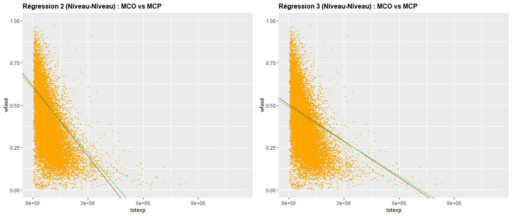

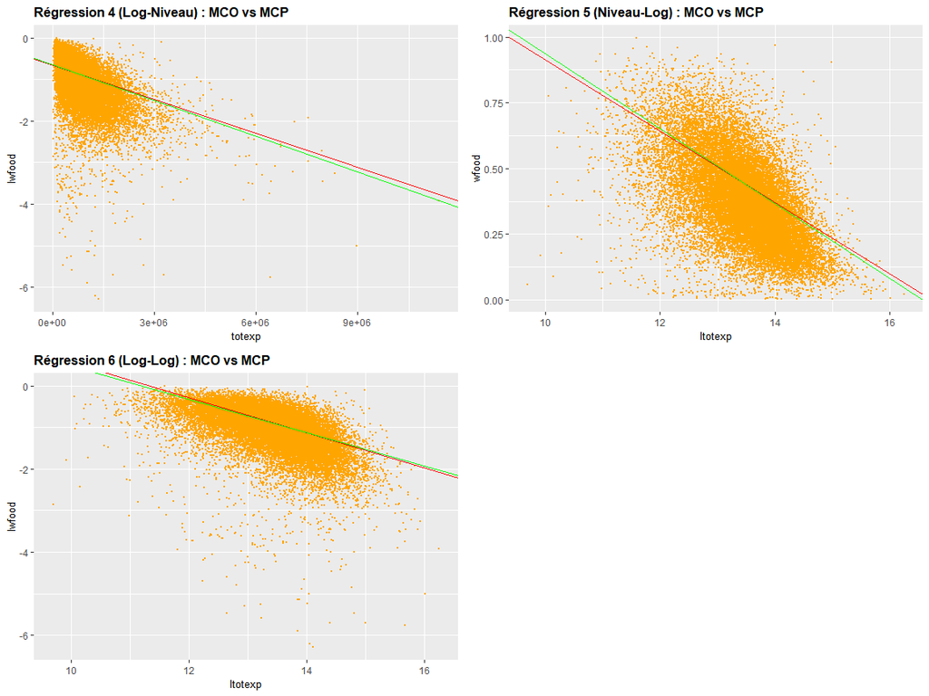

Il apparaît que l’utilisation de formes fonctionnelles (en l’ocurrence logartihmiques) semble réduire l’écart entre les 2 droites de régression. En effet, la droite estimée obtenue avec la méthode des MCO est plus colinéaire avec la droite estimée par MCP lorsque le modèle estimé comprend une forme logarithmique. L’adéquation la plus nette entre les deux droites se produit pour le modèle Log-Log qui correspond à la régression 6.

## Etude d’un sous-échantillon de **food**

On extrait un sous-échantillon aléatoire de 100 observations de la base de données **food**. On choisit les 100 premières observations afin d’éviter des changements dans les résultats lors de la compilation. L’objectif est d’étudier une éventuelle diminution des écarts-types estimés des coefficients estimés entre les modèles estimés par MCO et les modèles corrigés estimés par MCP. Il semble probable qu’en utlisant la méthode des MCP, il y ait moins de variabilité sur les coefficients des différents modèles. On suppose que les résultats seront plus significatifs sur un 100-échantillon que sur toute la base de données.

Pour chaque modèle, les résultats du premier test de Wald correspondent à la régression utilisant la méthode des MCO et et les résultats du second test de Wald correspondent à la régression utilisant la méthode des MCP. Nous utiliserons ces tests afin d’étudier l’évolution des écarts-types estimés après correction du modèle.

On effectura aussi un test de Breusch-Pagan pour détecter toute forme éventuelle d’hétéroscédasticité des résidus. On rappelle les hypothèses du test ici :
$$\left \{
\begin{array}{rcl}
H_0:V(\epsilon_i)=\sigma^2 \\
H_1 :V(\epsilon_i)=\sigma_i^2
\end{array}
\right.$$

```
##
## t test of coefficients:
##
##                   Estimate  Std. Error t value  Pr(>|t|)
## (Intercept)     5.6533e-01  3.5734e-02 15.8206 < 2.2e-16 ***
## totexp         -9.5941e-07  2.3897e-07 -4.0149 0.0001212 ***
## totexp:under25  8.3704e-07  2.3640e-07  3.5407 0.0006284 ***
## totexp:under50  8.2362e-07  2.3139e-07  3.5594 0.0005904 ***
## totexp:under75  8.1884e-07  2.2660e-07  3.6136 0.0004921 ***
## totexp:size1   -8.8119e-08  3.4821e-08 -2.5306 0.0130849 *
## totexp:size2   -3.5109e-08  1.8401e-08 -1.9080 0.0595100 .
## totexp:town1   -4.3395e-09  1.9340e-08 -0.2244 0.8229593
## ---
## Signif. codes:  0 '***' 0.001 '**' 0.01 '*' 0.05 '.' 0.1 ' ' 1
```

```
##
## t test of coefficients:
##
##                   Estimate  Std. Error t value  Pr(>|t|)
## (Intercept)     5.6195e-01  3.2493e-02 17.2943 < 2.2e-16 ***
## totexp         -9.5862e-07  2.0635e-07 -4.6457 1.126e-05 ***
## totexp:under25  8.4141e-07  2.0441e-07  4.1162 8.390e-05 ***
## totexp:under50  8.2384e-07  1.9955e-07  4.1285 8.021e-05 ***
## totexp:under75  8.1679e-07  1.9544e-07  4.1793 6.653e-05 ***
## totexp:size1   -8.8633e-08  3.3252e-08 -2.6655  0.009081 **
## totexp:size2   -3.0250e-08  1.6966e-08 -1.7830  0.077879 .
## totexp:town1   -2.5979e-09  1.7363e-08 -0.1496  0.881389
## ---
## Signif. codes:  0 '***' 0.001 '**' 0.01 '*' 0.05 '.' 0.1 ' ' 1
```

Résultats du test de Breusch-Pagan associé à la régression 3

|  | Statistique | Valeur critique | p-value |
| --- | --- | --- | --- |
| MCO | 7.75 | 14.07 | 0.36 |
| MCP | 7.75 | 14.07 | 0.36 |

On voit que la statistique du test de Breusch-Pagan est inférieure à la valeur critique $\chi^{2,\ 7}_{0.95} \approx 14.07$. Ainsi, on peut accepter l’hypothèse nulle d’homoscédasticité au risque $\alpha=5\%$. Aussi, la méthode des MCP semble permettre une diminution de la variabilité des coefficients estimés.

On procède désormais à la régression Log-Niveau suivante sur notre nouveau jeu de données réduit :
$$ln(wfood_{i}) = \beta_{0} + \beta_{1}totexp_{i} + \beta_{2}totexp_{i}\times under25+\beta_{3}totexp_{i}\times under50+\\ \beta_{4}totexp_{i}\times under75 \beta_{5}totexp_{i}\times size1 + \beta_{6}totexp_{i}\times size2 + \beta_{7}totexp_{i}\times town1+\varepsilon_{i}, \ \forall i$$

```
##
## t test of coefficients:
##
##                   Estimate  Std. Error t value  Pr(>|t|)
## (Intercept)    -5.5444e-01  1.3671e-01 -4.0556 0.0001046 ***
## totexp         -2.3468e-06  7.4802e-07 -3.1374 0.0022901 **
## totexp:under25  1.9715e-06  7.4530e-07  2.6452 0.0096015 **
## totexp:under50  1.9088e-06  7.1867e-07  2.6560 0.0093210 **
## totexp:under75  1.9438e-06  6.9565e-07  2.7942 0.0063319 **
## totexp:size1   -2.4127e-07  1.1702e-07 -2.0617 0.0420528 *
## totexp:size2   -9.3469e-08  6.9243e-08 -1.3499 0.1803709
## totexp:town1    3.4034e-08  7.1177e-08  0.4782 0.6336684
## ---
## Signif. codes:  0 '***' 0.001 '**' 0.01 '*' 0.05 '.' 0.1 ' ' 1
```

```
##
## t test of coefficients:
##
##                   Estimate  Std. Error t value  Pr(>|t|)
## (Intercept)    -5.6709e-01  1.3118e-01 -4.3230 3.893e-05 ***
## totexp         -2.3033e-06  7.3008e-07 -3.1549  0.002170 **
## totexp:under25  1.9262e-06  7.3310e-07  2.6275  0.010076 *
## totexp:under50  1.8755e-06  7.0364e-07  2.6654  0.009082 **
## totexp:under75  1.9041e-06  6.8182e-07  2.7927  0.006359 **
## totexp:size1   -2.2676e-07  1.1526e-07 -1.9674  0.052154 .
## totexp:size2   -9.3337e-08  7.3122e-08 -1.2764  0.205010
## totexp:town1    3.6259e-08  6.6162e-08  0.5480  0.584992
## ---
## Signif. codes:  0 '***' 0.001 '**' 0.01 '*' 0.05 '.' 0.1 ' ' 1
```

Résultats du test de Breusch-Pagan associé à la régression 4

|  | Statistique | Valeur critique | p-value |
| --- | --- | --- | --- |
| MCO | 2.57 | 14.07 | 0.92 |
| MCP | 2.57 | 14.07 | 0.92 |

Ici, on a $BP^* < \chi^{2,\ 7}_{0.95} \approx 14.07$. De fait, on accepte l’hypothèse d’homoscédasticité des résidus du modèle. La statistique du test de Breusch-Pagan est inférieure pour ce modèle Log-Niveau que pour le modèle Niveau-Niveau. On a donc une diminution de la variance des résidus en passant *wfood* au log.

Passons ensuite à la régression Niveau-Log suivante :
$$wfood_{i} = \beta_0 + \beta_1ln(totexp_i) + \beta_2ln(totexp_i)\times under25+\beta_{3}ln(totexp_i)\times under50 + \\ \beta_4ln(totexp_i)\times under75 +\beta_5ln(totexp_i)\times size1 + \beta_6ln(totexp_i)\times size2 + \beta_7ln(totexp_i)\times town1+\varepsilon_i, \ \forall i$$

```
##
## t test of coefficients:
##
##                   Estimate Std. Error t value  Pr(>|t|)
## (Intercept)      2.4400435  0.3725266  6.5500 3.248e-09 ***
## ltotexp         -0.1684625  0.0291556 -5.7781 1.021e-07 ***
## ltotexp:under25  0.0165825  0.0054594  3.0374 0.0031048 **
## ltotexp:under50  0.0179238  0.0056185  3.1901 0.0019452 **
## ltotexp:under75  0.0188100  0.0046975  4.0043 0.0001259 ***
## ltotexp:size1   -0.0045942  0.0025440 -1.8059 0.0742091 .
## ltotexp:size2   -0.0017068  0.0021979 -0.7766 0.4394068
## ltotexp:town1    0.0023624  0.0026262  0.8995 0.3707091
## ---
## Signif. codes:  0 '***' 0.001 '**' 0.01 '*' 0.05 '.' 0.1 ' ' 1
```

```
##
## t test of coefficients:
##
##                   Estimate Std. Error t value  Pr(>|t|)
## (Intercept)      2.6291229  0.3336490  7.8799 6.395e-12 ***
## ltotexp         -0.1827709  0.0263598 -6.9337 5.548e-10 ***
## ltotexp:under25  0.0184356  0.0050673  3.6382 0.0004529 ***
## ltotexp:under50  0.0195694  0.0051786  3.7789 0.0002794 ***
## ltotexp:under75  0.0201829  0.0044932  4.4918 2.047e-05 ***
## ltotexp:size1   -0.0051111  0.0024825 -2.0588 0.0423364 *
## ltotexp:size2   -0.0022485  0.0020874 -1.0772 0.2842173
## ltotexp:town1    0.0015553  0.0020730  0.7503 0.4549977
## ---
## Signif. codes:  0 '***' 0.001 '**' 0.01 '*' 0.05 '.' 0.1 ' ' 1
```

Résultats du test de Breusch-Pagan associé à la régression 5

|  | Statistique | Valeur critique | p-value |
| --- | --- | --- | --- |
| MCO | 10.58 | 14.07 | 0.16 |
| MCP | 10.58 | 14.07 | 0.16 |

On a $BP^* < \chi^{2,\ 7}_{0.95}$. On peut donc accepter l’hypothèse nulle d’homoscédasticité au risque 5%. De plus, l’utilisation des MCP permet une légère diminution des écarts-types estimés des coefficients.

Enfin, on applique la régréssion Log-Log à notre 100-échantillon:
$$ln(wfood_{i}) = \beta_{0} + \beta_{1}ln(totexp_{i}) + \beta_{2}ln(totexp_{i})\times under25+\beta_{3}ln(totexp_{i})\times under50 +\\ \beta_{4}ln(totexp_{i})\times under75 +\beta_{5}ln(totexp_{i})\times size1 + \beta_{6}ln(totexp_{i})\times size2 + \beta_{7}ln(totexp_{i})\times town1+\varepsilon_{i}, \ \forall i$$

```
##
## t test of coefficients:
##
##                   Estimate Std. Error t value  Pr(>|t|)
## (Intercept)      4.2143769  1.5640559  2.6945 0.0083794 **
## ltotexp         -0.4296571  0.1200797 -3.5781 0.0005546 ***
## ltotexp:under25  0.0389496  0.0197472  1.9724 0.0515650 .
## ltotexp:under50  0.0375517  0.0194459  1.9311 0.0565519 .
## ltotexp:under75  0.0445707  0.0147378  3.0242 0.0032304 **
## ltotexp:size1   -0.0145417  0.0083296 -1.7458 0.0841864 .
## ltotexp:size2   -0.0043933  0.0084258 -0.5214 0.6033325
## ltotexp:town1    0.0121419  0.0102315  1.1867 0.2383920
## ---
## Signif. codes:  0 '***' 0.001 '**' 0.01 '*' 0.05 '.' 0.1 ' ' 1
```

```
##
## t test of coefficients:
##
##                   Estimate Std. Error t value  Pr(>|t|)
## (Intercept)      4.5236520  1.2953970  3.4921 0.0007384 ***
## ltotexp         -0.4521480  0.0999894 -4.5220 1.823e-05 ***
## ltotexp:under25  0.0407440  0.0176422  2.3095 0.0231559 *
## ltotexp:under50  0.0401037  0.0174624  2.2966 0.0239129 *
## ltotexp:under75  0.0454616  0.0136940  3.3198 0.0012923 **
## ltotexp:size1   -0.0157029  0.0076969 -2.0402 0.0442012 *
## ltotexp:size2   -0.0049516  0.0077363 -0.6400 0.5237313
## ltotexp:town1    0.0105751  0.0095862  1.1032 0.2728325
## ---
## Signif. codes:  0 '***' 0.001 '**' 0.01 '*' 0.05 '.' 0.1 ' ' 1
```

Résultats du test de Breusch-Pagan associé à la régression 6

|  | Statistique | Valeur critique | p-value |
| --- | --- | --- | --- |
| MCO | 9.08 | 14.07 | 0.25 |
| MCP | 9.08 | 14.07 | 0.25 |

On relève une diminution plus marquées des écarts-types estimés d’une grande partie des coefficients lorsque l’on estime le modèle par MCP. On relève aussi plus de coefficients significatifs pour le modèle estimé par MCP. Pour le test de Breusch-Pagan, la *p-value* n’est pas significative. On ne peut pas rejeter l’hypothèse d’homoscédasticité des résidus.

**Conclusion**

Estimer un modèle par MCP semble donc efficace pour minimiser la variabilité des coefficients estimés. Aussi pour les modèles Niveau-Log et Log-Log, plus de coefficients sont significatifs lorsque l’on estime le modèle par MCP.

Notons cependant que la mise au logarithme de la variable explicative *totexp* tout en gardant la variable dépendante en niveau semble moins efficace pour réduire la variance des résidus.

Ainsi, sur notre 100-échantillon, les résultats des tests (Fisher, Student,…) seront plus pertinents pour les régressions faites par MCP plutôt que pour celles faites par MCO.